# **Food Access and Social Determinants of Health Affecting Obesity Rates**

*Github link:* https://amylng.github.io/

**The Team:** Nina Moore, Amy Le Nguyen

## **Motivation & Project Goals**

Obesity has been cited as an "epidemic" in America ([Harvard Gazette](https://news.harvard.edu/gazette/story/2025/10/researchers-report-astounding-obesity-surge-in-u-s/)), and nearly half of adults in America are considered obese ([CDC NCHS Data Brief](https://www.cdc.gov/nchs/products/databriefs/db508.htm)). This is extremely concerning, as obesity has been linked to increased risk for type 2 diabetes, kidney disease, and even certain kinds of cancer ([NIH](https://www.niddk.nih.gov/health-information/weight-management/adult-overweight-obesity/health-risks)).

There have been research efforts in the fields of public health and data science to explore the individual factors that predispose someone to obesity ([CDC](https://www.cdc.gov/obesity/risk-factors/risk-factors.html)), but we were curious about contributors to obesity rate on the state level. Obesity as a public health issue is a combination of socioeconomic and political factors, and we aim to identify which variables are the largest contributors to obesity rate on the state level and whether geography predetermines an American's health outcomes.

Our project seeks to better understand which socioeconomic factors in the USA during 2015 most accurately affect the obesity rates in each of the states. Obesity is a wide-ranging issue in the United States and there are many unseen factors outside of individual control that contribute to the obesity rates in the USA. To assist us in this study, we have chosen three datasets.

Dataset 1:

- *[National Obesity Percentages by State (Data.gov):](https://catalog.data.gov/dataset/national-obesity-by-state-d765a)* Lists percentages of state population considered obese from a 2015 CDC survey. This serves as the basis for our data analysis.

This dataset is key to our analysis as it provides the obesity percentages in each state in 2015.

Dataset 2:

- *[Social Determinants of Health Database (Agency for Healthcare Research and Quality):](https://www.ahrq.gov/sdoh/data-analytics/sdoh-data.html)* A dataset with measures of 330 social determinants of health across all 50 states, with specificity by county, in 2015. We plan to look at race, median household income, percentage of households that have food stamps, etc.

This dataset introduces socioeconomic factors that will help us to determine if race is a key factor in the obesity rates seen in each state.

Dataset 3:

- *[Food Environmental Atlas (USDA):](https://www.ers.usda.gov/data-products/food-environment-atlas/data-access-and-documentation-downloads)* Measures access to food statewide for all 50 states. It considers variables like grocery stores, dollar stores, fast food restaurants, sit-down restaurants in the county.

This dataset is key as it provides data about the access to stores and therefore helps us to determine if the access to nutritious food is a factor in the obesity rates seen in each state.

Through the cleaning and analysis of these three datasets, we are building towards models that answer the following questions:

1. Are lower-income populations and populations with lower access to food more disproportionately affected by obesity?
2. How does race come into play when it comes to obesity? Are some races at a disadvantage when it comes to food access and/or obesity?
3. Are there any obvious geographic disparities? How significant is geographic region with respect to obesity rate?

# Data Processing: Extraction, Transformation, Loading

To gain the insights necessary to answer the questions we're interested in, we need to load and tidy the data.

```python
# run program to access files from google drive
from google.colab import drive
drive.mount('/content/drive')
```

```python
# import necessary libraries
import pandas as pd
import numpy as np
import matplotlib.pyplot as plt
import seaborn as sns
from sklearn.preprocessing import StandardScaler

# change directory
%cd /content/drive/MyDrive/Colab Notebooks/Data Science Project
```

```
/content/drive/MyDrive/Colab Notebooks/Data Science Project
```

## **Dataset 1:**

The first data set to be loaded in focuses on the National Obesity Percentages by State.

```python
# load in 'National Obesity Percentages by State' dataset
obesity_percents_df = pd.read_csv('obesity_perc.csv',skiprows=1)
obesity_percents_df.head()
```

|  | OBJECTID | NAME | Obesity | Shape__Area | Shape__Length |
| --- | --- | --- | --- | --- | --- |
| 0 | 1 | Texas | 32.4 | 7.672329e+12 | 1.540832e+07 |
| 1 | 2 | California | 24.2 | 5.327809e+12 | 1.451870e+07 |
| 2 | 3 | Kentucky | 34.6 | 1.128830e+12 | 6.346699e+06 |
| 3 | 4 | Georgia | 30.7 | 1.652980e+12 | 5.795596e+06 |
| 4 | 5 | Wisconsin | 30.7 | 1.567816e+12 | 6.806782e+06 |

We only need access to the Name and Obesity columns, so the Shape_Area and Shape_Length columns are dropped. The new dataframe with the last two columns dropped is called `obesity_perc`. Since we are only considereing the 50 States, Puerto Rico was dropped.

```python
# a list of the column names we want in the cleaned data frame
columns_s = ["NAME","Obesity"]
# creates an original dataframe based off off the obesity_percents_df dataframe with only the specified columns. Makes sure that modifications don't affect original df
obesity_perc = obesity_percents_df[columns_s].copy()
delete = ['Puerto Rico']
#deletes Puerto Rico from the cleaned dataframe
obesity_perc = obesity_perc[~obesity_perc['NAME'].isin(delete)]
```

We want to discover which states have the highest and lowest percentages of obesity. We will perform the `.max()` and `.min()` operations on the Obesity column, respectively, to report those findings.

```python
#Displays the row with the state with the maximum obesity percentage
max_o = obesity_perc.loc[obesity_perc["Obesity"].idxmax()]
max_o
```

|  | 8 |
| --- | --- |
| NAME | Louisiana |
| Obesity | 36.2 |

**dtype:** object

```python
#Displays the row with the state with the minimum obesity percentage
min_o = obesity_perc.loc[obesity_perc["Obesity"].idxmin()]
min_o
```

|  | 25 |
| --- | --- |
| NAME | Colorado |
| Obesity | 20.2 |

**dtype:** object

The above operations tell us that Louisiana has the highest obesity at 36.2% and Colorado has the lowest obesity percentage at 20.2%.

We also want to discover the national average obesity percentage in 2015, the year this data was collected.

```python
# Displays the national average obesity rate in 2015
avg_o = obesity_perc["Obesity"].mean()
print(avg_o)
```

```
29.28235294117647
```

Therefore in the USA, the national average obesity percentage was 29.2%.

Below is a chart that displays the obesity rates per state, including where each lies with respect to the national average obesity rate.

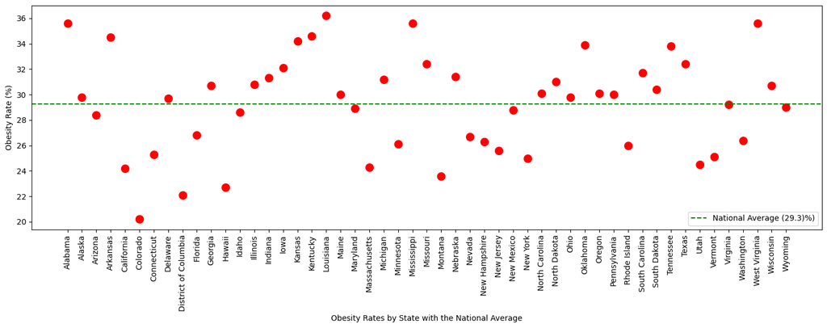

```python
#sorts the state names so that they are in order
sort_ob = obesity_perc.sort_values(by="NAME").reset_index(drop=True)
plt.figure(figsize=(15,6))
plt.scatter(sort_ob["NAME"],sort_ob["Obesity"],color='red',s=100)
#creates the line for the national average rate of obesity
plt.axhline(avg_o,color='green',linestyle='--',label=f'National Average ({avg_o:.1f})%)')
plt.xticks(rotation=90)
plt.ylabel("Obesity Rate (%)")
plt.xlabel("Obesity Rates by State with the National Average")
plt.legend()
plt.tight_layout()
```

## **Dataset 2:**

The Social Determinants of Health Database is 85530 x 330. Instead of loading in such a large database every time, we'll load in the variables of interest:

- State
- Percent American Indian and Native American
- Percent Asian
- Percent Black
- Percent Native Hawaiian and Pacific Islander
- Percent White
- Percent Unemployed
- Median Household Income
- Percent of Households with Food Stamps
- Percent of Households with Food Stamps Below the Poverty Line

The original dataset also included U.S. territories, which were dropped, as we are only considering the 50 states.

```python
# load in 'Social Determinants of Health Database'
# only consider columns with variables of interest
sdoh_df = pd.read_csv('SDOH_2015.csv', usecols=['STATE', 'COUNTY', 'ACS_PCT_AIAN_COMB',
                       'ACS_PCT_ASIAN_COMB', 'ACS_PCT_BLACK_COMB',
                       'ACS_PCT_NHPI_COMB', 'ACS_PCT_WHITE_COMB',
                       'ACS_PCT_UNEMPLOY', 'ACS_MEDIAN_HH_INC',
                       'ACS_PCT_HH_FOOD_STMP', 'ACS_PCT_HH_FOOD_STMP_BLW_POV']
                        )
# drop US territories
territories = ['Puerto Rico', 'Guam', 'American Samoa',
               'Northern Mariana Islands', 'US Virgin Islands']
sdoh_df = sdoh_df[~sdoh_df['STATE'].isin(territories)]

sdoh_df.head()
```

|  | STATE | COUNTY | ACS_PCT_AIAN_COMB | ACS_PCT_ASIAN_COMB | ACS_PCT_BLACK_COMB | ACS_PCT_NHPI_COMB | ACS_PCT_WHITE_COMB | ACS_PCT_UNEMPLOY | ACS_MEDIAN_HH_INC | ACS_PCT_HH_FOOD_STMP | ACS_PCT_HH_FOOD_STMP_BLW_POV |
| --- | --- | --- | --- | --- | --- | --- | --- | --- | --- | --- | --- |
| 0 | Alabama | Autauga County | 1.49 | 1.28 | 8.06 | 0.87 | 91.38 | 5.42 | 61838.0 | 15.21 | 6.60 |
| 1 | Alabama | Autauga County | 0.51 | 4.78 | 53.48 | 0.00 | 44.25 | 13.35 | 32303.0 | 30.59 | 17.56 |
| 2 | Alabama | Autauga County | 2.06 | 1.92 | 18.56 | 2.93 | 79.28 | 6.22 | 44922.0 | 11.98 | 4.51 |
| 3 | Alabama | Autauga County | 2.31 | 0.00 | 4.61 | 0.00 | 83.88 | 10.81 | 54329.0 | 2.47 | 0.49 |
| 4 | Alabama | Autauga County | 0.00 | 4.57 | 26.23 | 0.29 | 70.58 | 4.20 | 51965.0 | 13.73 | 5.48 |

An interesting variable to consider with regard to obesity is food stamp usage across each state. Let's try to find which states have the highest and lowest percentage of households with foodstamps and compare this with the states with the highest and lowest obesity rates.

Since the original database separates information by county, which we will ignore, we need to group each variable of interest by state and consider only the percent of households with food stamps. We'll take the average in order to take the average percentage of food stamp usage across all the counties and find which states have the highest and lowest percentage of households with foodstamps.

```python
# group dataset by state and consider food stamps usage
# find the mean to get the state average (average across all counties)
avg_food_stamps = sdoh_df.groupby('STATE')['ACS_PCT_HH_FOOD_STMP'].mean()

# find state with the highest percentage
print('State with Highest Percentage of Households with Foodstamps:',
      avg_food_stamps.idxmax(), ',', round(avg_food_stamps.max(), 2), '%')
# find state with the lowest percentage
print('State with Lowest Percentage of Households with Foodstamps:',
      avg_food_stamps.idxmin(), ',', round(avg_food_stamps.min(), 2), '%')

# get a look at the first few states
avg_food_stamps.head()
```

```
State with Highest Percentage of Households with Foodstamps: Mississippi , 20.1 %
State with Lowest Percentage of Households with Foodstamps: Wyoming , 6.04 %
```

| STATE | ACS_PCT_HH_FOOD_STMP |
| --- | --- |
| Alabama | 18.318511 |
| Alaska | 11.940723 |
| Arizona | 14.596766 |
| Arkansas | 16.250920 |
| California | 9.959721 |

**dtype:** float64

From this, it looks like the state with the highest percentage of households with foodstamps is Mississippi, with 20.1% of households having foodstamps in the state. In contrast, only 6.04% of households in Wyoming have foodstamps, the lowest in the nation. These don't align with Louisiana and Colorado having the highest and lowest obesity rates, but we'll do a more in-depth analysis of these variables in our EDA section.

Median household income would also be helpful to consider, as it's intuitive to think that states with higher median household incomes would have fewer households on foodstamps and, therefore, lower obesity rates. Let's see if this is true just by looking at the states with the highest and lowest median household incomes.

The same process of taking the average across all the counties is done to find the median household income for each state. We'll locate where and find the highest and lowest median households incomes in America and compare these to the foodstamps and obesity rate findings above.

```python
# group social determinants of health dataset by state
# only consider the median household income variable and find the mean
avg_income = sdoh_df.groupby('STATE')['ACS_MEDIAN_HH_INC'].mean()

# find state with highest median household income
print('State with Highest Median Household Income:', avg_income.idxmax(),
      ', $', round(avg_income.max(), 2))
# find state with lowest median household income
print('State with Lowest Median Household Income:', avg_income.idxmin(),
      ', $', round(avg_income.min(), 2))

# get a look at the first few states
avg_income.head()
```

```
State with Highest Median Household Income: Maryland , $ 79136.84
State with Lowest Median Household Income: Mississippi , $ 38909.92
```

| STATE | ACS_MEDIAN_HH_INC |
| --- | --- |
| Alabama | 43296.358603 |
| Alaska | 70354.743902 |
| Arizona | 54207.820955 |
| Arkansas | 41935.633968 |
| California | 67333.661390 |

**dtype:** float64

It seems that Mississippi has both the lowest median household in America and the highest percentage of households with foodstamps. This insinuates there is a strong negative correlation between these two variables (as household income increases, the population on foodstamps decreases), but we will explore the relationship between these two variables and how they each correlate with obesity rate in the next section.

## **Dataset 3:**

The Food Environmental Atlas dataset has over 300 variables, many of which are for years other than 2015, which is our year of interest. We will only consider the variables of interest for 2015:

- State
- County
- Low access to store, 2015
- Low access to store and low-income, 2015
- Households, no car & low access to store, 2015
- SNAP households, low access to store, 2015
- White, low access to store, 2015
- Black, low access to store, 2015
- Hispanic, low access to store, 2015
- Asian, low access to store, 2015
- American Indian or Alaska Native, low access to store, 2015
- Hawaiian or Pacific Islander, low access to store, 2015
- Multiracial, low access to store, 2015
- Food distribution centers on Native American reservations, 2015
- Adult diabetes rate, 2015

The 'State' column will be mapped so that each imported dataset is using the full state names, rather than the abbreviations, so that it is consistent with the rest of the datasets. Additionally, there are some negative diabetes rates in the 'Adult diabetes rate, 2015' data (presumably because there was no or missing data), so any rows with negative values will be dropped.

```python
# low-access populations
access_df = pd.read_csv('atlas_access.csv',
                       usecols=['State', 'County', 'LACCESS_POP15',
                       'LACCESS_LOWI15', 'LACCESS_HHNV15',
                       'LACCESS_SNAP15', 'LACCESS_WHITE15',
                       'LACCESS_BLACK15', 'LACCESS_HISP15',
                       'LACCESS_ASIAN15', 'LACCESS_AIAN15',
                       'LACCESS_HOPI15', 'LACCESS_MULTIR15'])

# food distribution centers on indian reservations
assistance_df = pd.read_csv('atlas_assistance.csv', usecols=['State', 'County',
                                                             'FDPIR15'])

# adult diabetes rates
diabetes_df = pd.read_csv('atlas_health.csv', usecols=['State', 'County',
                                                       'PCT_DIABETES_ADULTS15'])

# dictionary mapping abbreviations → full names
state_abbrev_to_name = {
    'AL': 'Alabama', 'AK': 'Alaska', 'AZ': 'Arizona', 'AR': 'Arkansas', 'CA': 'California',
    'CO': 'Colorado', 'CT': 'Connecticut', 'DE': 'Delaware', 'FL': 'Florida', 'GA': 'Georgia',
    'HI': 'Hawaii', 'ID': 'Idaho', 'IL': 'Illinois', 'IN': 'Indiana', 'IA': 'Iowa',
    'KS': 'Kansas', 'KY': 'Kentucky', 'LA': 'Louisiana', 'ME': 'Maine', 'MD': 'Maryland',
    'MA': 'Massachusetts', 'MI': 'Michigan', 'MN': 'Minnesota', 'MS': 'Mississippi',
    'MO': 'Missouri', 'MT': 'Montana', 'NE': 'Nebraska', 'NV': 'Nevada', 'NH': 'New Hampshire',
    'NJ': 'New Jersey', 'NM': 'New Mexico', 'NY': 'New York', 'NC': 'North Carolina',
    'ND': 'North Dakota', 'OH': 'Ohio', 'OK': 'Oklahoma', 'OR': 'Oregon', 'PA': 'Pennsylvania',
    'RI': 'Rhode Island', 'SC': 'South Carolina', 'SD': 'South Dakota', 'TN': 'Tennessee',
    'TX': 'Texas', 'UT': 'Utah', 'VT': 'Vermont', 'VA': 'Virginia', 'WA': 'Washington',
    'WV': 'West Virginia', 'WI': 'Wisconsin', 'WY': 'Wyoming', 'DC': 'District of Columbia'
}

# replace abbreviations with full names
access_df['State'] = access_df['State'].map(state_abbrev_to_name)
assistance_df['State'] = assistance_df['State'].map(state_abbrev_to_name)
diabetes_df['State'] = diabetes_df['State'].map(state_abbrev_to_name)

# drop diabetes rates that are negative
diabetes_df = diabetes_df[diabetes_df['PCT_DIABETES_ADULTS15'] >= 0]

display(access_df.head())
display(assistance_df.head())
display(diabetes_df.head())
```

|  | State | County | LACCESS_POP15 | LACCESS_LOWI15 | LACCESS_HHNV15 | LACCESS_SNAP15 | LACCESS_WHITE15 | LACCESS_BLACK15 | LACCESS_HISP15 | LACCESS_ASIAN15 | LACCESS_AIAN15 | LACCESS_HOPI15 | LACCESS_MULTIR15 |
| --- | --- | --- | --- | --- | --- | --- | --- | --- | --- | --- | --- | --- | --- |
| 0 | Alabama | Autauga | 18092.661350 | 6835.642497 | 677.672769 | 1822.537716 | 28592.192360 | 6645.162299 | 790.187847 | 188.457143 | 161.635647 | 15.711041 | 866.714452 |
| 1 | Alabama | Baldwin | 46400.350640 | 15459.848420 | 1394.162766 | 4874.837779 | 114569.054500 | 10709.565460 | 5400.587834 | 792.906323 | 971.615628 | 51.305996 | 4554.710751 |
| 2 | Alabama | Barbour | 6683.975691 | 3251.362574 | 425.144927 | 1357.606370 | 9924.136304 | 8196.688099 | 1055.536003 | 65.276832 | 101.195583 | 13.961786 | 896.003741 |
| 3 | Alabama | Bibb | 295.614426 | 164.903295 | 224.388125 | 972.185555 | 14775.827540 | 3775.872254 | 304.346057 | 16.574243 | 50.485583 | 3.915621 | 295.702565 |
| 4 | Alabama | Blount | 5855.939161 | 2570.900481 | 719.931444 | 2685.697327 | 48763.477090 | 552.119031 | 3827.607930 | 84.023054 | 279.703754 | 36.186185 | 2526.713164 |

|  | State | County | FDPIR15 |
| --- | --- | --- | --- |
| 0 | Alabama | Autauga | 0 |
| 1 | Alabama | Baldwin | 0 |
| 2 | Alabama | Barbour | 0 |
| 3 | Alabama | Bibb | 0 |
| 4 | Alabama | Blount | 0 |

|  | State | County | PCT_DIABETES_ADULTS15 |
| --- | --- | --- | --- |
| 0 | Alabama | Autauga | 9.1 |
| 1 | Alabama | Baldwin | 8.6 |
| 2 | Alabama | Barbour | 12.7 |
| 3 | Alabama | Bibb | 9.9 |
| 4 | Alabama | Blount | 9.9 |

## **Creating 2 New Dataframes**

Now that all 3 necessary datasets have been inputed and cleaned, certain features from each dataset will be concatenated into a single dataset to better understand which socioeconomic factors are highly correlated with obesity percentage. We want to create two dataframes that are related through the state column, one dataframe that doesn't have any variables related to race and another that has variables related to race. From these two dataframes, we will determine where race-based factors vs. non-race based factors are highly correlated with obesity percentages.

Now, we will create the first dataframe focusing on non-race based socioeconomic factors in the USA in 2015. To create this dataset, we will use the following columns from each of the datasets.

Dataset # 1

- NAME
- Obesity
- Obesity_sc

Dataset # 2

- STATE
- COUNTY
- ACS_PCT_UNEMPLOY
- ACS_MEDIAN_HH_INC
- ACS_PCT_HH_FOOD_STMP
- ACS_PCT_HH_FOOD_STMP_BLW_POV

-- Not Used --

- ACS_PCT_AIAN_COMB
- ACS_PCT_ASIAN_COMB
- ACS_PCT_BLACK_COMB
- ACS_PCT_NHPI_COMB
- ACS_PCT_WHITE_COMB

Dataset # 3

- State
- County
- LACCESS_POP15
- LACCESS_LOWI15
- LACCESS_HHNV15
- LACCESS_SNAP15

-- Not Used --

- LACCESS_WHITE15
- LACCESS_BLACK15
- LACCESS_HISP15
- LACCESS_ASIAN15
- LACCESS_AIAN15
- LACCESS_HOPI15
- LACCESS_MULTIR15

from `access_df`

- State
- County
- FDPIR15

from the `assistance_df`

- State
- County
- PCT_DIABETES_ADULTS15

from the `diabetes_df`

For the last two datasets we will need to groupby states since these datasets contain the data for states by counties.

In the **first dataset** we need to rename the state column of the dataset to be clearer.

```python
obesity_perc.rename(columns={'NAME': 'State'}, inplace=True)
obesity_perc.head(3)
```

|  | State | Obesity |
| --- | --- | --- |
| 0 | Texas | 32.4 |
| 1 | California | 24.2 |
| 2 | Kentucky | 34.6 |

For the **second dataset** we need to first average all the column data values from each of the counties in a state so that we can look at the socioeconomic features from a state view.

```python
df_2 = sdoh_df.groupby('STATE',as_index=False).mean(numeric_only=True)
```

Then we will rename the columns so that they are easier to understand given the documentation on the dataset.

```python
df_2.rename(columns={'STATE': 'State', 'ACS_PCT_AIAN_COMB': 'Percent American Indian','ACS_PCT_ASIAN_COMB': 'Percent Asian',
                     'ACS_PCT_BLACK_COMB': 'Percent Black','ACS_PCT_NHPI_COMB': 'Percent Native Hawaian',
                     'ACS_PCT_WHITE_COMB': 'Percent White','ACS_PCT_UNEMPLOY': 'Percent Unemployed',
                     'ACS_MEDIAN_HH_INC': 'Median Household Income','ACS_PCT_HH_FOOD_STMP': 'Percent Household Foodstamps',
                     'ACS_PCT_HH_FOOD_STMP_BLW_POV': 'Percent Household Foodstamps (Below Poverty Line)'}, inplace=True)
```

We will separate the columns that aren't race related.

```python
df_2_no_race = df_2.drop(columns=[
    'Percent American Indian',
    'Percent Asian',
    'Percent Black',
    'Percent Native Hawaian',
    'Percent White'
])
```

For the **third dataset** we will do something similar. This includes dropping the columns from `access_df`, `assistance_df`, and `diabetes_df` that include race features, renaming the columns, and grouping data by state

```python
# get rid of any negative values that may affect the groupby function when averaging

# Replace negatives with NaN only in numeric columns
access_df[access_df.select_dtypes(include='number').columns] = \
    access_df.select_dtypes(include='number').apply(lambda x: x.where(x >= 0, np.nan))

assistance_df[assistance_df.select_dtypes(include='number').columns] = \
    assistance_df.select_dtypes(include='number').apply(lambda x: x.where(x >= 0, np.nan))

diabetes_df[diabetes_df.select_dtypes(include='number').columns] = \
    diabetes_df.select_dtypes(include='number').apply(lambda x: x.where(x >= 0, np.nan))

# Now group by State and take the mean (ignores NaN automatically)
access_3 = access_df.groupby('State', as_index=False).mean(numeric_only=True)
assistance_3 = assistance_df.groupby('State', as_index=False).mean(numeric_only=True)
diabetes_3 = diabetes_df.groupby('State', as_index=False).mean(numeric_only=True)
```

```python
#rename the columns from the food environmental atlas dataframe from the access sheet
one = access_3.rename(columns={'LACCESS_POP15':'Low Access to Store','LACCESS_LOWI15':'Low Income & Low Store Access','LACCESS_HHNV15':'No Car & Low Store Access',
                          'LACCESS_SNAP15':'SNAP & Low Store Access','LACCESS_WHITE15':'Low Store Access- Whites','LACCESS_BLACK15':'Low Store Access- Blacks',
                          'LACCESS_HISP15':'Low Store Access- Hispanics','LACCESS_ASIAN15':'Low Store Access- Asians','LACCESS_AIAN15':'Low Store Access- American Indian',
                          'LACCESS_HOPI15':'Low Store Access- Hawaian','LACCESS_MULTIR15':'Low Store Access- Multirace'})
one.head(2)
```

|  | State | Low Access to Store | Low Income & Low Store Access | No Car & Low Store Access | SNAP & Low Store Access | Low Store Access- Whites | Low Store Access- Blacks | Low Store Access- Hispanics | Low Store Access- Asians | Low Store Access- American Indian | Low Store Access- Hawaian | Low Store Access- Multirace |
| --- | --- | --- | --- | --- | --- | --- | --- | --- | --- | --- | --- | --- |
| 0 | Alabama | 17290.036637 | 6382.565391 | 868.654832 | 2524.026442 | 32720.167821 | 8964.194779 | 1412.931584 | 365.140414 | 306.952345 | 22.152596 | 1339.959882 |
| 1 | Alaska | 8362.622084 | 2312.975756 | 465.624533 | 480.047595 | 9627.427799 | 269.249645 | 586.739656 | 427.648519 | 2242.883510 | 58.855512 | 995.637697 |

```python
#rename the columns from the food environmental atlas dataframe from the assistance sheet
two = assistance_3.rename(columns={'FDPIR15':'Number of Food Asistance Sites'})
two.head(2)
```

|  | State | Number of Food Asistance Sites |
| --- | --- | --- |
| 0 | Alabama | 0.00000 |
| 1 | Alaska | 0.62069 |

```python
diabetes_3.columns
```

```
Index(['State', 'PCT_DIABETES_ADULTS15'], dtype='object')
```

```python
#rename the columns from the food environmental atlas dataframe from the assistance sheet that mention the adult diabetes percentage for each state
three = diabetes_3.rename(columns={'PCT_DIABETES_ADULTS15':'Adult Diabetes (%)'})
three.head(2)
```

|  | State | Adult Diabetes (%) |
| --- | --- | --- |
| 0 | Alabama | 10.607463 |
| 1 | Alaska | 7.779310 |

Now we will edit dataset `one` to only contain non-race based features for our first dataframe.

```python
one.columns
```

```
Index(['State', 'Low Access to Store', 'Low Income & Low Store Access',
       'No Car & Low Store Access', 'SNAP & Low Store Access',
       'Low Store Access- Whites', 'Low Store Access- Blacks',
       'Low Store Access- Hispanics', 'Low Store Access- Asians',
       'Low Store Access- American Indian', 'Low Store Access- Hawaian',
       'Low Store Access- Multirace'],
      dtype='object')
```

```python
# drop columns from the one dataset that don't pertain to race
one_no_race = one.drop(columns=['Low Store Access- Whites', 'Low Store Access- Blacks',
       'Low Store Access- Hispanics', 'Low Store Access- Asians',
       'Low Store Access- American Indian',
       'Low Store Access- Hawaian', 'Low Store Access- Multirace'])
one_no_race.head(2)
```

|  | State | Low Access to Store | Low Income & Low Store Access | No Car & Low Store Access | SNAP & Low Store Access |
| --- | --- | --- | --- | --- | --- |
| 0 | Alabama | 17290.036637 | 6382.565391 | 868.654832 | 2524.026442 |
| 1 | Alaska | 8362.622084 | 2312.975756 | 465.624533 | 480.047595 |

Before we concatenate all the previous datasets into the non-race based dataframe, we need to check the formating of the state column in each dataset to see if joining on the 'State' column will introduce any errors.

```python
# checking the length of the state columns in each of the dataframes to make sure they match up
a = len(obesity_perc["State"].unique())
b = len(df_2_no_race["State"].unique())
c = len(one_no_race["State"].unique())
d = len(two["State"].unique())
e = len(three["State"].unique())


print(a,b,c,d,e)
```

```
51 51 51 51 51
```

Since they are the same length (the 50 states and D.C.), we will now join on the state variable for all these datasets.

```python
merged_norace = obesity_perc.merge(df_2_no_race, on="State") \
                    .merge(one_no_race, on="State") \
                    .merge(two, on="State") \
                    .merge(three, on="State")
merged_norace.head(2)
```

|  | State | Obesity | Percent Unemployed | Median Household Income | Percent Household Foodstamps | Percent Household Foodstamps (Below Poverty Line) | Low Access to Store | Low Income & Low Store Access | No Car & Low Store Access | SNAP & Low Store Access | Number of Food Asistance Sites | Adult Diabetes (%) |
| --- | --- | --- | --- | --- | --- | --- | --- | --- | --- | --- | --- | --- |
| 0 | Texas | 32.4 | 7.392127 | 56023.764559 | 14.906890 | 7.932985 | 26801.991420 | 9462.353780 | 587.351788 | 1775.916041 | 0.003937 | 7.581496 |
| 1 | California | 24.2 | 10.191150 | 67333.661390 | 9.959721 | 5.095669 | 85983.158099 | 23070.822414 | 1430.181887 | 2877.566334 | 1.448276 | 7.796552 |

Now, we will create the second dataframe that uses race-based features.

```python
#creates the list of columns that are race based and includes them into a dataframe
cols = list(set(df_2.columns) - set(df_2_no_race.columns))
keep = ['State'] + [col for col in cols if col != 'State']
df2_race = df_2[keep]
df2_race.head(2)
```

|  | State | Percent American Indian | Percent Asian | Percent Black | Percent White | Percent Native Hawaian |
| --- | --- | --- | --- | --- | --- | --- |
| 0 | Alabama | 1.192934 | 1.356956 | 32.129235 | 65.577857 | 0.104940 |
| 1 | Alaska | 22.424132 | 7.184850 | 4.552754 | 71.495988 | 1.606826 |

```python
cols_o = list(set(one.columns) - set(one_no_race.columns))
keep_o = ['State'] + [col for col in cols_o if col != 'State']
one_race = one[keep_o]
one_race.head(2)
```

|  | State | Low Store Access- Whites | Low Store Access- American Indian | Low Store Access- Hispanics | Low Store Access- Hawaian | Low Store Access- Multirace | Low Store Access- Blacks | Low Store Access- Asians |
| --- | --- | --- | --- | --- | --- | --- | --- | --- |
| 0 | Alabama | 32720.167821 | 306.952345 | 1412.931584 | 22.152596 | 1339.959882 | 8964.194779 | 365.140414 |
| 1 | Alaska | 9627.427799 | 2242.883510 | 586.739656 | 58.855512 | 995.637697 | 269.249645 | 427.648519 |

```python
merged_race = obesity_perc.merge(df2_race, on="State") \
                    .merge(one_race, on="State")
merged_race.head(2)
```

|  | State | Obesity | Percent American Indian | Percent Asian | Percent Black | Percent White | Percent Native Hawaian | Low Store Access- Whites | Low Store Access- American Indian | Low Store Access- Hispanics | Low Store Access- Hawaian | Low Store Access- Multirace | Low Store Access- Blacks | Low Store Access- Asians |
| --- | --- | --- | --- | --- | --- | --- | --- | --- | --- | --- | --- | --- | --- | --- |
| 0 | Texas | 32.4 | 1.238374 | 4.301666 | 12.812967 | 77.467911 | 0.175177 | 31275.171514 | 275.128355 | 13187.837292 | 37.138405 | 4453.654306 | 4259.383729 | 1194.359977 |
| 1 | California | 24.2 | 1.925680 | 15.112483 | 7.100046 | 66.120831 | 0.760790 | 82615.548636 | 1526.822721 | 33237.805879 | 346.685942 | 19527.990922 | 5812.577238 | 10576.393372 |

We have created two dataframes for our resulting analysis and model:

- `merged_norace`
- `merged_race`

Let's check the data types of each of the columns in these merged dataframes

```python
merged_norace.dtypes
```

|  | 0 |
| --- | --- |
| State | object |
| Obesity | float64 |
| Percent Unemployed | float64 |
| Median Household Income | float64 |
| Percent Household Foodstamps | float64 |
| Percent Household Foodstamps (Below Poverty Line) | float64 |
| Low Access to Store | float64 |
| Low Income & Low Store Access | float64 |
| No Car & Low Store Access | float64 |
| SNAP & Low Store Access | float64 |
| Number of Food Asistance Sites | float64 |
| Adult Diabetes (%) | float64 |

**dtype:** object

```python
merged_race.dtypes
```

|  | 0 |
| --- | --- |
| State | object |
| Obesity | float64 |
| Percent American Indian | float64 |
| Percent Asian | float64 |
| Percent Black | float64 |
| Percent White | float64 |
| Percent Native Hawaian | float64 |
| Low Store Access- Whites | float64 |
| Low Store Access- American Indian | float64 |
| Low Store Access- Hispanics | float64 |
| Low Store Access- Hawaian | float64 |
| Low Store Access- Multirace | float64 |
| Low Store Access- Blacks | float64 |
| Low Store Access- Asians | float64 |

**dtype:** object

All the columns are float64 so an int except the state column which is good. We can now uses these dataframes for EDA and modeling

In our Exploratory Data Analysis and Visualization section, we will use these two dataframes to create a correlation matrix heatmap in order to narrow our focus to a select few variables that have the highest contribution to obesity rate.

# Exploratory Data Analysis and Visualization

Now that the data has been loaded, cleaned, and tidied, we can use it to gain an intuition for how certain variables correlate with obesity before creating our models. This is done to better answer some questions about how social determinants of health and food access affect obesity.

**Hypothesis**: Lower-income populations and those with lower access to food are more affected by obesity. To confirm or reject this hypothesis, we will perform EDA on variables related to income and food access within each database that we loaded in.

## Topics of Interest from Dataset 2: Social Determinants of Health Database

### Relationship between Median Household Income, Food Stamps Prevalence, and Obesity Rate

The Social Determinants of Health Database had information about race, employment status, median household income, and foodstamps prevalence. Immediately, median household income and foodstamps prevalence stuck out as potential contributors to obesity, and we were curious about how these two variables might correlate with each other.

To get a feel for how median household income might correlate with food access, which we believe has implications on obesity, we'll plot our median household income data against our percentage of households with food stamps. Does median income in the state correlate with how prevalent food stamps are? Later, we'll see if this matches up with obesity and food stamps metrics.

```
Correlation between Median Household Income ($) vs. Food Stamps Prevalence: -0.531
```

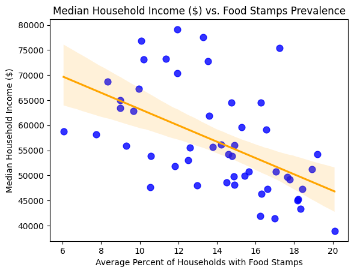

```python
# find correlation value between percentage of households with food stamps
# and median household income
corr_value = avg_food_stamps.corr(avg_income)
print(f"Correlation between Median Household Income ($) vs. Food Stamps Prevalence: {corr_value:.3f}")

# plot percentage of households with food stamps against median household income
sns.regplot(
    x=avg_food_stamps,
    y=avg_income,
    scatter_kws={"color": "blue", "s": 60},
    line_kws={"color": "orange"}
)
plt.xlabel('Average Percent of Households with Food Stamps')
plt.ylabel('Median Household Income ($)')
plt.title('Median Household Income ($) vs. Food Stamps Prevalence')
plt.show()
```

Just looking at the graph, there seems to be a negative correlation between median household income and percentage of households with food stamps. That is, as median household income increases, the average percent of households with foodstamps decreases. In reality, this means that states with lower median household incomes often have higher percentages of households on food stamps. Soon, we will explore how obesity correlates with both of these variables, but this exploratory analysis gives insight on how wealth affects food access.

Overall, this finding is reassuring and matches with our intuition, as we saw earlier that Mississippi had both the lowest median household income and the highest percent of households on foodstamps.

The plot below depicts Median Household Income vs. Obesity Rate.

```
Correlation between median household income and obesity rate: -0.694
```

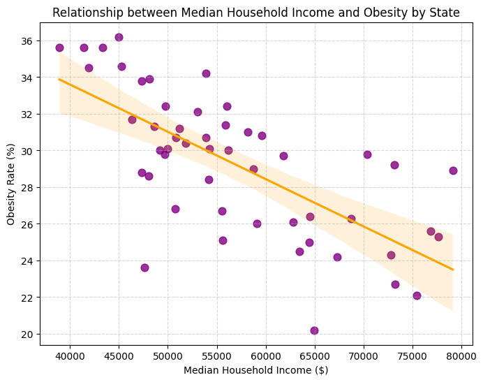

```python
income_obesity_corr = merged_norace["Median Household Income"].corr(merged_norace["Obesity"])
print(f"Correlation between median household income and obesity rate: {income_obesity_corr:.3f}")

plt.figure(figsize=(8,6))
sns.regplot(
    data=merged_norace,
    x="Median Household Income",
    y="Obesity",
    scatter_kws={"color": "purple", "s": 60},
    line_kws={"color": "orange"}
)
plt.title("Relationship between Median Household Income and Obesity by State")
plt.xlabel("Median Household Income ($)")
plt.ylabel("Obesity Rate (%)")
plt.grid(True, linestyle="--", alpha=0.5)
plt.show()
```

The correlation between the two variables is -0.694, indicating that there is a moderate-strong relationship between the two. In reality, this means that as median household income decreases, obesity rate increases. That is, states with lower median household incomes often have higher obesity rates.

Given this relationship and the fact that median household income and foodstamps prevalence also has a negative correlation, it seems that an increase in foodstamps prevalence should result in an increase in obesity rate. To confirm this, we will use Seaborn again to find the correlation between and plot foodstamps prevalence as a function of obesity.

```
Correlation between percentage of households with food stamps and obesity rate: 0.459
```

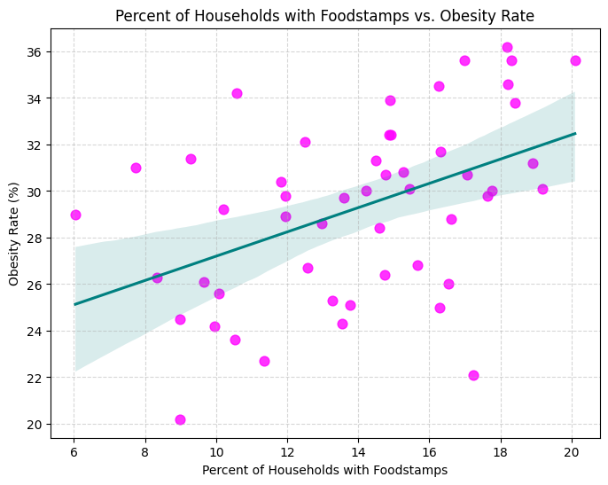

```python
income_obesity_corr = merged_norace["Percent Household Foodstamps"].corr(merged_norace["Obesity"])
print(f"Correlation between percentage of households with food stamps and obesity rate: {income_obesity_corr:.3f}")

plt.figure(figsize=(8,6))
sns.regplot(
    data=merged_norace,
    x="Percent Household Foodstamps",
    y="Obesity",
    scatter_kws={"color": "magenta", "s": 60},
    line_kws={"color": "teal"}
)
plt.title("Percent of Households with Foodstamps vs. Obesity Rate")
plt.xlabel("Percent of Households with Foodstamps")
plt.ylabel("Obesity Rate (%)")
plt.grid(True, linestyle="--", alpha=0.5)
plt.show()
```

From the graph above and the moderate correlation of 0.459, this result aligns with our intuitions: as the percentage of households with foodstamps increases, the obesity rate also increases. This indicates that food access might be an underlying factor that affects obesity rates and disproportionately affects lower-income populations.

Additionally, we can visualize the relationship between these three variables through the graph of Percent of Households with Foodstamps vs. Median Household income, with the marker colors indicating obesity rate.

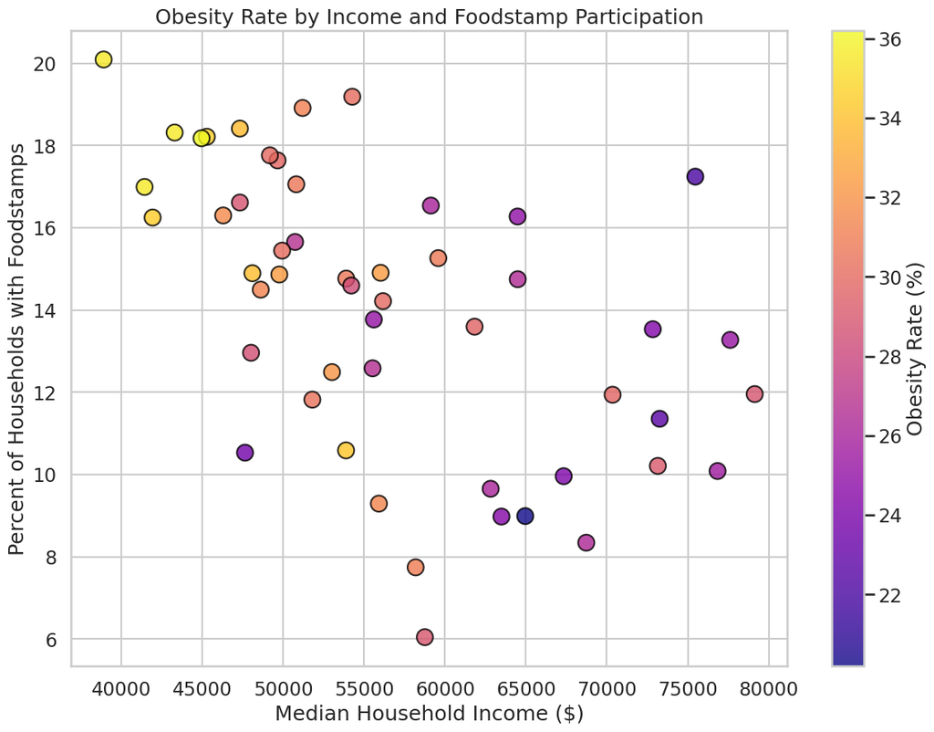

```python
# seaborn styling
sns.set_style("whitegrid")
sns.set_context("talk")

# X, Y, Z
x = merged_norace["Median Household Income"]
y = merged_norace["Percent Household Foodstamps"]
z = merged_norace["Obesity"]
states = merged_norace["State"]

plt.figure(figsize=(14, 10))

sc = plt.scatter(
    x, y,
    c=z,
    cmap="plasma",
    s=200,               # larger markers
    edgecolor="k",       # black edges
    alpha=0.8            # slightly transparent
)

plt.xlabel("Median Household Income ($)")
plt.ylabel("Percent of Households with Foodstamps")
plt.title("Obesity Rate by Income and Foodstamp Participation", fontsize=18)

# colorbar for obesity rate
cbar = plt.colorbar(sc)
cbar.set_label("Obesity Rate (%)")

plt.show()
```

This reiterates the information from above, but more clearly, it can be seen that in the lower right-hand side, where Median Household Income is high and Percent of Households with Foodstamps is low, the obesity rates also tend to be low. In fact, following the graph from left to right, it can be seen that the obesity rates are highest at the lowest median household incomes and highest prevalence of households with foodstamps.

This trend aligns with our hypothesis: lower-income populations (states with lower median household incomes and higher percentages of households with foodstamps) are more affected by obesity.

## Topics of Interest from Dataset 3: Environmental Food Atlas

### Relationship between Population with Low Access to Food and Obesity Rate

We'll take a look at how populations with low access to food are affected by obesity. In the Food Atlas dataset, 'LACCESS_POP15' records the number of individuals in each county of the US that are said to have low access to food. The raw population counts are not very helpful to us, as states with larger total populations will naturally have a higher low-access population. We need a fairer way to compare between states, so we'll create what we call `state_contribution`.

In order to properly assess states' rates of low access to food, we'll take the sum of the 'LACCESS_POP15' column to find the total low-access population across the United States. Then, we'll use each state's individual low-access population counts to see what percentage of low-access individuals live in each state. This is what the `state_contribution` variable is.

```python
# total low-access population across all counties
total_low_access = access_df['LACCESS_POP15'].sum()

# add up low-access population by state
state_low_access = access_df.groupby('State')['LACCESS_POP15'].sum()

# normalize each state's low-access population by total
# this gives a sense of to national contribution
state_contribution = state_low_access / total_low_access

# sort to see which states contribute most to low food access
state_contribution_sorted = state_contribution.sort_values(ascending=False)

# print states with highest and lowest state contributions to low access to food
display(state_contribution_sorted.head())
print('State with largest rate of population with low access to food: ',
      state_contribution_sorted.idxmax(), ', ',
       round(state_contribution_sorted.max() * 100, 2), '%')
print('State with smallest rate of population with low access to food: ',
      state_contribution_sorted.idxmin(), ', ',
      round(state_contribution_sorted.min() * 100, 2), '%')
```

| State | LACCESS_POP15 |
| --- | --- |
| Texas | 0.098283 |
| California | 0.071997 |
| Florida | 0.069747 |
| Georgia | 0.043100 |
| Ohio | 0.042165 |

**dtype:** float64

```
State with largest rate of population with low access to food:  Texas ,  9.83 %
State with smallest rate of population with low access to food:  District of Columbia ,  0.02 %
```

Using this method, we see that 9.83% of the United States's low-access to food population is located in Texas. In contrast, only 0.02% of the country's population with low access to food is located in Washington, D.C.

We still want to see how state contribution and obesity percentages correlate with each other, however. Since they are on different scales, however (the maximum for `state_contribution` is 9.83% vs. 36.2% for `obesity_perc`), so we will z-score standardize the data.

```python
# z-score state contribution
state_contribution_sc = (state_contribution - np.mean(state_contribution)) / np.std(state_contribution)
display(state_contribution_sc.head())

# calculate z-score
obesity_perc["Obesity_sc"] = ((obesity_perc["Obesity"] - np.mean(obesity_perc["Obesity"])) /
                              np.std(obesity_perc["Obesity"]))
obesity_perc = obesity_perc.sort_values("State")
display(obesity_perc.head())
```

| State | LACCESS_POP15 |
| --- | --- |
| Alabama | -0.150920 |
| Alaska | -0.842977 |
| Arizona | 0.239548 |
| Arkansas | -0.498236 |
| California | 2.741924 |

**dtype:** float64

|  | State | Obesity | Obesity_sc |
| --- | --- | --- | --- |
| 37 | Alabama | 35.6 | 1.648349 |
| 13 | Alaska | 29.8 | 0.135060 |
| 42 | Arizona | 28.4 | -0.230216 |
| 23 | Arkansas | 34.5 | 1.361346 |
| 1 | California | 24.2 | -1.326046 |

Now that they are on comparable scales, we can plot each state's low access to food population against its obesity percentages.

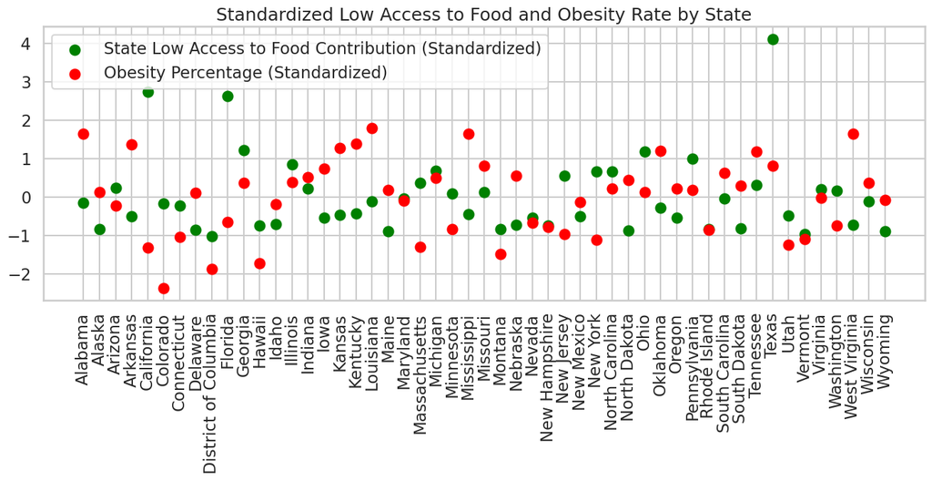

```python
# plot state contribution with low access for each state
plt.figure(figsize=(16,5))
plt.scatter(state_contribution.index, state_contribution_sc.values,
            color='green',s=100, label='State Low Access to Food Contribution (Standardized)')
plt.scatter(state_contribution.index, obesity_perc["Obesity_sc"], color='red',
            s=100, label='Obesity Percentage (Standardized)')
plt.xticks(rotation=90)
plt.grid(True)
plt.legend()
plt.title('Standardized Low Access to Food and Obesity Rate by State')
plt.show()
```

This visualization allows us to compare these variables on a state level, but it is difficult to gauge any real correlation between the variables. To do so, we'll simply plot the unstandardized points and find the correlation between the two using seaborn.

```
Correlation between low access to food and obesity: -0.439
```

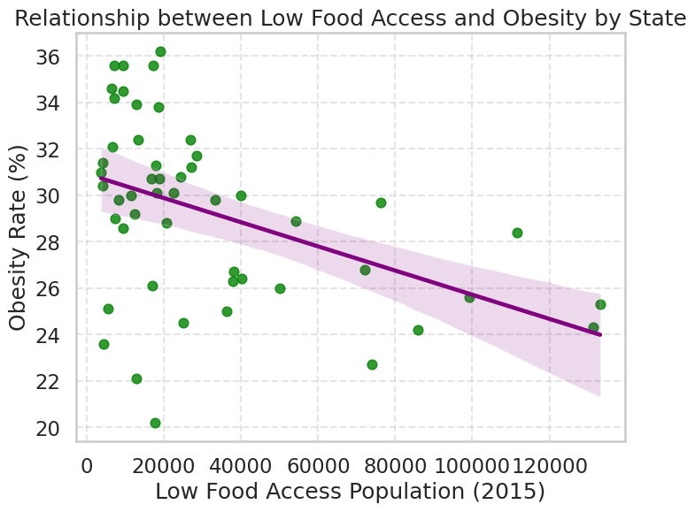

```python
# define low-access to food variable from access_df
low_access = access_df.groupby("State", as_index=False)["LACCESS_POP15"].mean()

# merge low_access with obesity_perc
merged = pd.merge(low_access, obesity_perc, left_on="State", right_on="State", how="inner")

# calculate correlation value between the two variables
corr_value = merged["LACCESS_POP15"].corr(merged["Obesity"])
print(f"Correlation between low access to food and obesity: {corr_value:.3f}")

# plot
plt.figure(figsize=(8,6))
sns.regplot(
    data=merged,
    x="LACCESS_POP15",
    y="Obesity",
    scatter_kws={"color": "green", "s": 60},
    line_kws={"color": "purple"}
)
plt.title("Relationship between Low Food Access and Obesity by State")
plt.xlabel("Low Food Access Population (2015)")
plt.ylabel("Obesity Rate (%)")
plt.grid(True, linestyle="--", alpha=0.5)
plt.show()
```

The correlation between low food access population and obesity rate is -0.439. This means that obesity rates decrease within a state as the population with low food access increases.

This finding does not match with our hypothesis, which was that populations with lower access to food are more affected by obesity. Low access to food is still important to consider, however, given its correlation with obesity. When creating our model, we will be sure to include this variable.

### How Adult Diabetes Rate and Obesity Rate Correlate

Finally, as a last step for our exploratory analysis of data from the Food Atlas, we will find the correlation between diabetes and obesity rate using the `.corr()` function and visualizing it using seaborn's `sns.regplot()` function.

```
Correlation between diabetes rate and obesity rate: 0.568
```

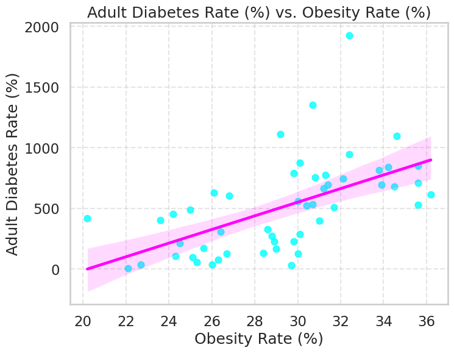

```python
# group diabetes data by state
diabetes_by_state = diabetes_df.groupby('State', as_index=False)['PCT_DIABETES_ADULTS15'].sum()

# calculate correlation
diabetes_obesity_corr = merged_norace["Obesity"].corr(merged_norace["Adult Diabetes (%)"])
print(f"Correlation between diabetes rate and obesity rate: {diabetes_obesity_corr:.3f}")

# plot
plt.figure(figsize=(8,6))
sns.regplot(
    x= obesity_perc["Obesity"],
    y= diabetes_by_state['PCT_DIABETES_ADULTS15'],
    scatter_kws={"color": "cyan", "s": 60},
    line_kws={"color": "magenta"})
plt.title("Adult Diabetes Rate (%) vs. Obesity Rate (%)")
plt.xlabel("Obesity Rate (%)")
plt.ylabel("Adult Diabetes Rate (%)")
plt.grid(True, linestyle="--", alpha=0.5)
plt.show()
```

## Quick Aside: Mapping Obesity Rate, Median Household Income, and Percent of Households with Foodstamps by State

Using the geopandas library, we were able to geographically map the above information. Hopefully, this serves as an accessible visualization of these relationships!

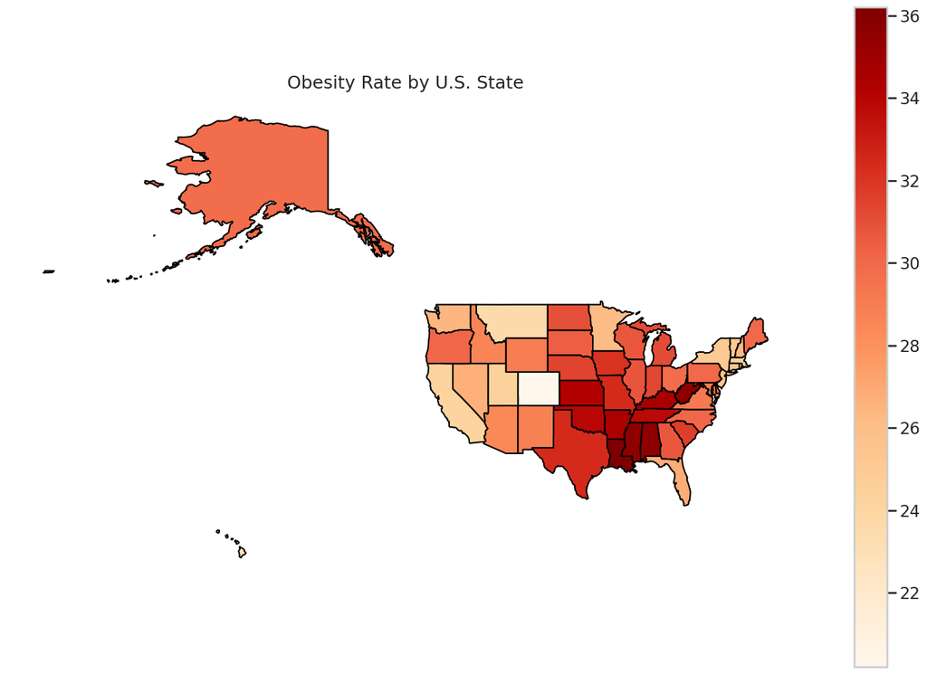

```python
import geopandas as gpd

states_gpd = gpd.read_file("https://raw.githubusercontent.com/PublicaMundi/MappingAPI/master/data/geojson/us-states.json")

df = merged_norace.copy()

# Merge using the State column
merged = states_gpd.merge(df, left_on="name", right_on="State")

# Plot the heatmap
merged.plot(
    column="Obesity",
    cmap="OrRd",
    legend=True,
    edgecolor="black",
    figsize=(18, 12)
)
plt.title("Obesity Rate by U.S. State")
plt.axis("off")
plt.show()
```

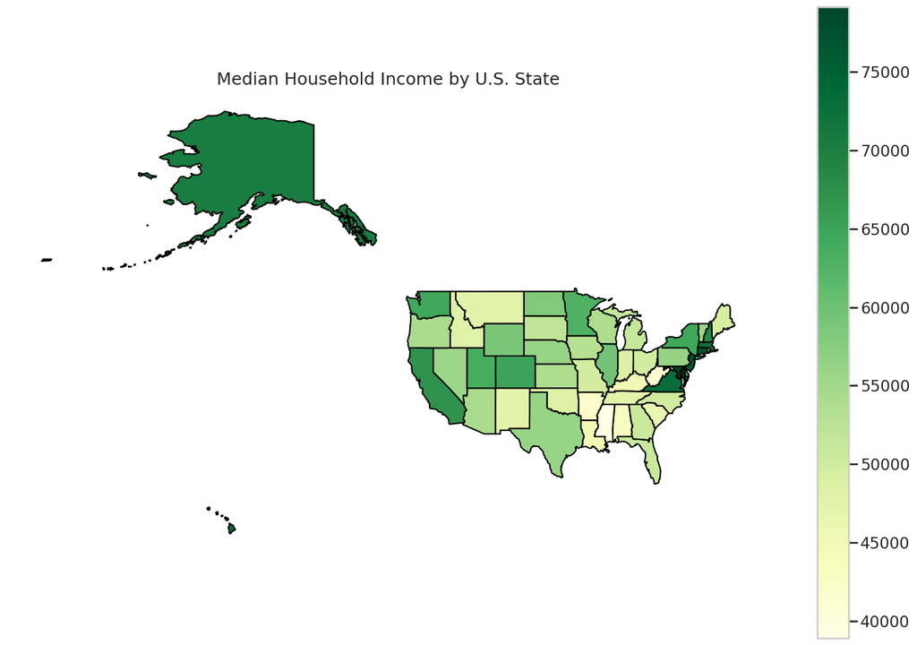

```python
merged.plot(
    column="Median Household Income",
    cmap="YlGn",
    legend=True,
    edgecolor="black",
    figsize=(18, 12)
)
plt.title("Median Household Income by U.S. State")
plt.axis("off")
plt.show()
```

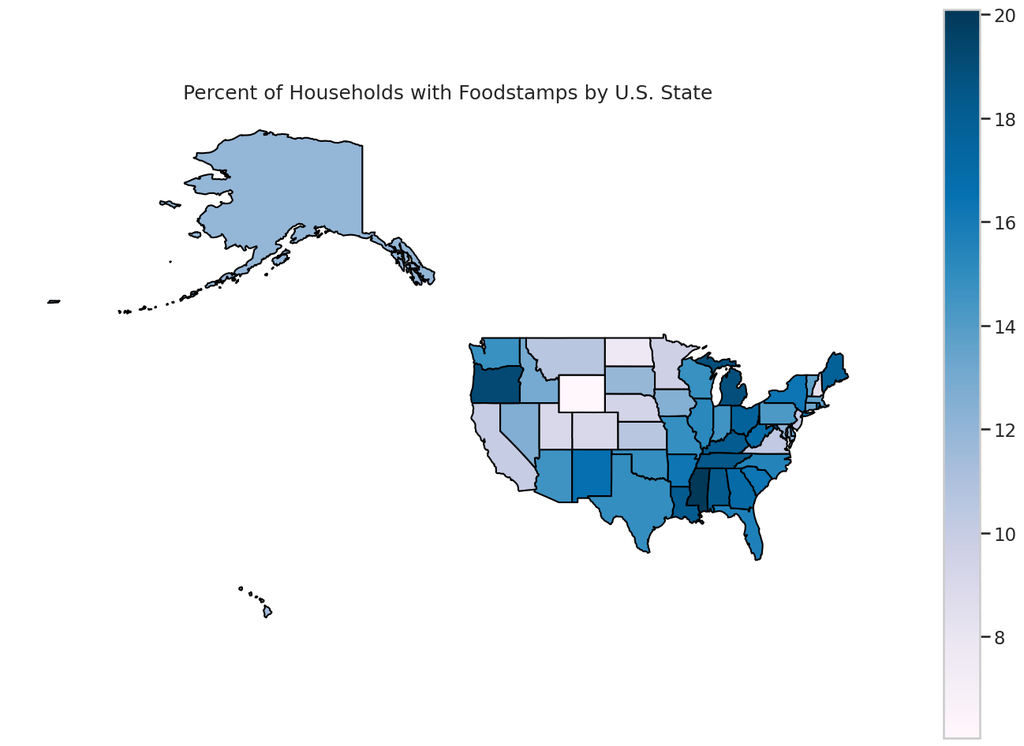

```python
merged.plot(
    column="Percent Household Foodstamps",
    cmap="PuBu",
    legend=True,
    edgecolor="black",
    figsize=(18, 12)
)
plt.title("Percent of Households with Foodstamps by U.S. State")
plt.axis("off")
plt.show()
```

## Correlation Heat Map Using Merged Dataframes

After gaining these insights from the individual datasets, we have explored variables that potentially have the most significant relationships with obesity. To see how every variable of interest correlates with obesity, however, we will use Seaborn to create a heatmap.

We will employ a correlation matrix on both `merged_norace` and `merged_race` dataframes to determine which two models we could create that can predict obesity percentage more accurately. However, we first need to create a version of the dataframes without the `State` column, as a correlation matrix works only on numeric values.

```python
# merged_norace
corr_norace = merged_norace.drop(columns='State').corr()
# merged_race
corr_race = merged_race.drop(columns='State').corr()
```

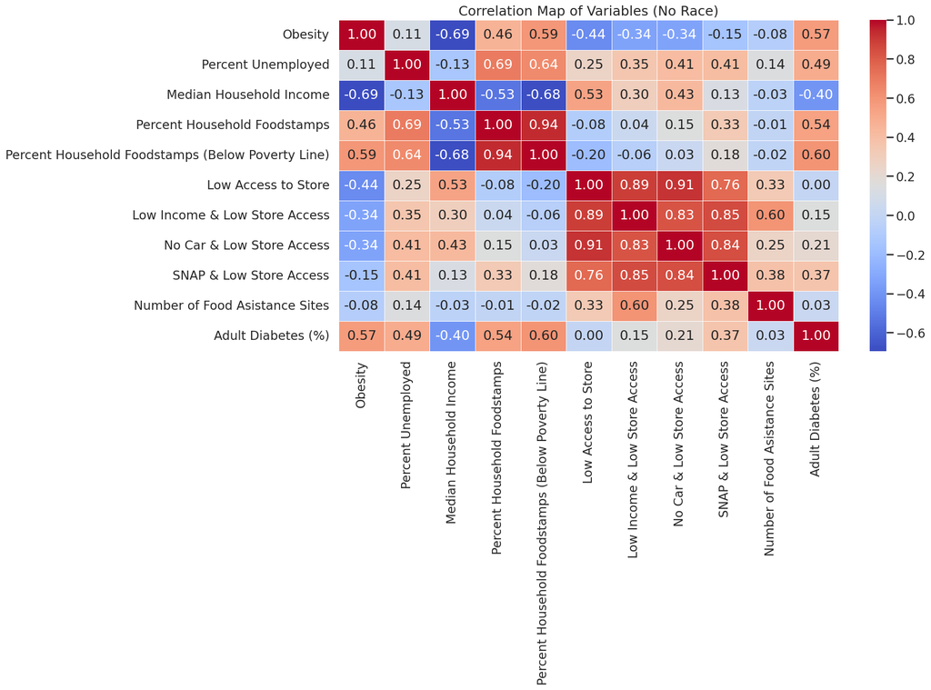

```python
# for no race
plt.figure(figsize=(15, 8))
sns.heatmap(corr_norace, annot=True, cmap='coolwarm', fmt=".2f", linewidths=.5)
plt.title('Correlation Map of Variables (No Race)')
plt.show()
```

From this correlation heat map, it can be seen that variables that deal with low store access are highly correlated with one another. This is expected, but this correlation matrix cements the idea that store access is a significant factor to consider. When considering factors that affect obesity specifically, 'Median Household Income' and 'Percent Household Foodstamps' seem to have moderate-high correlations.

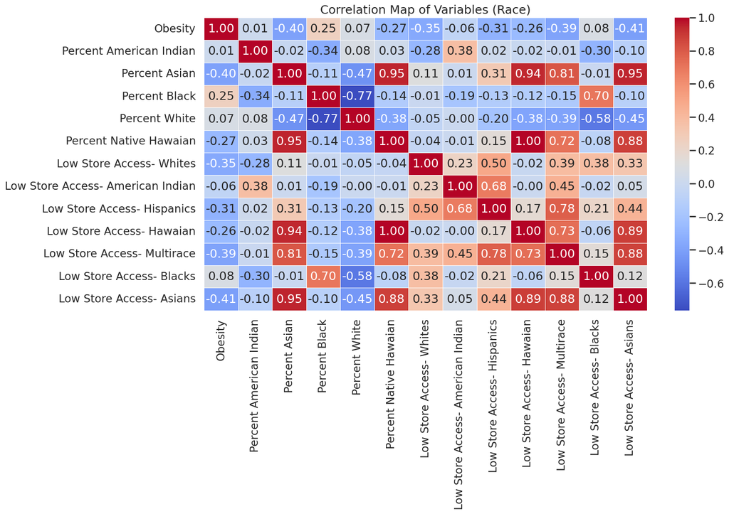

```python
# for race
plt.figure(figsize=(15, 8))
sns.heatmap(corr_race, annot=True, cmap='coolwarm', fmt=".2f", linewidths=.5)
plt.title('Correlation Map of Variables (Race)')
plt.show()
```

The correlation heat maps above show that race may not be a very significant factor in percentages of obesity in a state. This is shown by how there are fewer variables with a high correlation value in the merged dataframe focusing just on race-based scoioeconomic factors that the dataframe that focuses on non-race based socioeconomic factors.

# Analysis, Hypothesis Testing, Machine Learning (Model)

After analyzing the correlation matrices above, we're interested in creating two models:

- **Obesity Rate Predictor**: Using linear regression, we chose median household income, percent of households with foodstamps, low access to store, and adult diabetes rate to predict obesity rate. This answers the following question: How are Americans' health outcomes predetermined by their geographic location (state)? If validation proves the model accurate, then it seems that state-level factors (like foodstamps prevalence within a state) have a strong effect on individual health.
- **A Classifier to Investigate Geographic Disparities**: Can a k-nearest neighbors classifier accurately predict what region a state lies within given the information in `merged_norace`? This question and model are relevant because if a state's nearest neighbor is within the same region as the state itself, then that means obesity-related variables follow major census region boundaries. For example, if Louisiana's (the state with the highest obesity rate) nearest neighbors are all in the South, then it is implied that geographic regions correspond to real-world differences in obesity, food access, income, etc.

### Linear Regression Model: Predicting Obesity Rate

**Hypothesis**: A person with a low median house income that lives in an area with a low access to food stores and high diabetes rates is more likely to be obese than a person who doesn’t

Since our feature variables are on different scales, we will use the StandardScaler() fucntion to prevent poor algorithm performance and low accuracy.

We will use the Pipeline package to make scaling and prediction easier to accomplish.

```python
from sklearn.model_selection import LeaveOneOut
from sklearn.preprocessing import StandardScaler
from sklearn.linear_model import LinearRegression
from sklearn.pipeline import Pipeline
from sklearn.model_selection import cross_val_score
from sklearn.metrics import mean_squared_error, r2_score, mean_absolute_error
```

First, we need to create our features and target matrices. The features matrix will contain our x or independant variables. For this model, these will include

- `Percent Household Foodstamps (Below Poverty Line)`: the state percentage of households with foodstamps who are also below the poverty line
- `Adult Diabetes (%)`: the adult diabetes rate in the state
- `Median Household Income`: the median household income in the state
- `Low Access to Store`: the population of people who are considered to have low access to food

The target matrix will contain the y or dependent variable. This is the value we are trying to predict. For this model this variable is `Obesity(%)` (state obesity rate).

```python
merged_norace.columns
```

```
Index(['State', 'Obesity', 'Percent Unemployed', 'Median Household Income',
       'Percent Household Foodstamps',
       'Percent Household Foodstamps (Below Poverty Line)',
       'Low Access to Store', 'Low Income & Low Store Access',
       'No Car & Low Store Access', 'SNAP & Low Store Access',
       'Number of Food Asistance Sites', 'Adult Diabetes (%)'],
      dtype='object')
```

```python
features_cols = ["Percent Household Foodstamps (Below Poverty Line)","Median Household Income","Adult Diabetes (%)","Low Access to Store"]
x_o = merged_norace[features_cols].copy()
y_o = merged_norace["Obesity"].copy()
states = merged_norace["State"].copy()
```

Let's create the pipeline that will standardize our x variables and then fit them into the linear regression model.

```python
pipeline = Pipeline([
    ('scaler',StandardScaler()),
    ('regressor',LinearRegression())
])
```

Now, the LOOCV validation method can be implemented.

```python
loo = LeaveOneOut()
```

We will initially train the model with the LOOCV data validation method manually for evaluation. This is to see how the model performs on unseen data. We use manual LOOCV iteration instead of:

- `cross_val_score(pipeline, X, y, cv=loo, scoring='r2')`

```python
all_predictions = []
all_actuals = []
state_names = []
# Run LOOCV manually to collect all predictions since when it was done using the built in method we got an inaccurate R2 score
for train_idx, test_idx in loo.split(x_o):
    # Split data
    X_train, X_test = x_o.iloc[train_idx], x_o.iloc[test_idx]
    y_train, y_test = y_o.iloc[train_idx], y_o.iloc[test_idx]

    # Fit and predict
    pipeline.fit(X_train, y_train)

    #Predict
    y_pred = pipeline.predict(X_test)[0]
    y_actual = y_test.values[0]

    # Store results
    all_predictions.append(y_pred)
    all_actuals.append(y_actual)
    state_names.append(states.iloc[test_idx].values[0])

#Covert results to numpy arrays
all_predictions = np.array(all_predictions)
all_actuals = np.array(all_actuals)
```

Now that we have trained the final model, we will set up some validation metrics to determine the accuracy of the model. To do this we will calculate the mean-sqaured error, R2 score, and mean absolute error.

- The mean-squared error measures the average of the squared differences between predicted values and actual values.
- The R2 score measures how well a regression model fits the observed data.
- The mean absolute error average magnitude of errors in a model's predictions.

```python
# Calculate metrics
cv_r2 = r2_score(all_actuals, all_predictions)
cv_rmse = np.sqrt(mean_squared_error(all_actuals, all_predictions))
cv_mae = mean_absolute_error(all_actuals, all_predictions)

print(f"\nCross-Validation Results:")
print(f"  R2 Score: {cv_r2:.4f}")
print(f"  Model explains {cv_r2*100:.1f}% of variance in state obesity rates")

print("")
print(f"Root Mean Squared Error (RMSE): {cv_rmse:.2f} percentage points")
print(f"  Average magnitude of prediction errors")

print("")
print(f"Mean Absolute Error (MAE): {cv_mae:.2f} percentage points")
print(f"  Typical prediction is within ±{cv_mae:.1f} percentage points")
```

```
Cross-Validation Results:
  R2 Score: 0.4695
  Model explains 46.9% of variance in state obesity rates

Root Mean Squared Error (RMSE): 2.79 percentage points
  Average magnitude of prediction errors

Mean Absolute Error (MAE): 2.15 percentage points
  Typical prediction is within ±2.2 percentage points
```

With an R2 score of ~0.47 this means that the model does a Moderate job at fitting the observed data. This means that the model captures almost half of patterns from the data, but the other half comes from other factors not in the model.

A RMSE of 2.79 means that the average difference between the models predicted values and the actual values. Since the obesity percentage values range from 20.2% to 36.2%, a total of 16 percentage points, this is (2.79/16) = 17% of the total range of values and therefore a pretty good RMSE. The model makes reasonable accurate predictions.

A MAE of 2.15 percentage points also means that for our data the model makes reasonable predictions.

Now let's examine how many states were predicted accurately and the spread of predictions versus the spread of actual values.

```python
# Prediction accuracy breakdown
errors = np.abs(all_actuals - all_predictions)
within_1 = (errors <= 1).sum()
within_2 = (errors <= 2).sum()
within_3 = (errors <= 3).sum()

print(f"\n  • Prediction Accuracy:")
print(f"    - Within ±1 percentage point: {within_1}/50 states ({within_1/50*100:.0f}%)")
print(f"    - Within ±2 percentage points: {within_2}/50 states ({within_2/50*100:.0f}%)")
print(f"    - Within ±3 percentage points: {within_3}/50 states ({within_3/50*100:.0f}%)")

# Variance analysis
pred_variance = np.var(all_predictions)
actual_variance = np.var(all_actuals)

print(f"\n  • Variance Analysis:")
print(f"    - Actual obesity variance: {actual_variance:.2f}")
print(f"    - Predicted obesity variance: {pred_variance:.2f}")
print(f"    - Ratio: {pred_variance/actual_variance:.2%}")
if pred_variance < actual_variance:
    print(f"    → Model predictions are more conservative (narrower range than reality)")
```

```
  • Prediction Accuracy:
    - Within ±1 percentage point: 12/50 states (24%)
    - Within ±2 percentage points: 30/50 states (60%)
    - Within ±3 percentage points: 40/50 states (80%)

  • Variance Analysis:
    - Actual obesity variance: 14.69
    - Predicted obesity variance: 9.76
    - Ratio: 66.44%
    → Model predictions are more conservative (narrower range than reality)
```

The prediction accuracy is good but could be better. For example, 60% of states predicted within ± 2 points, suggesting that the model predicts in the right area most of the time. The variance anlysis shows that the model predictions are conservative, only capturing only 66% of real variation. This means that on average high obesity rate states are predicted lower and low-obesity rate states are predicted higher. However, since only 4 features were used, this is reasonable.

Now let's train one final model on all data.

```python
pipeline.fit(x_o,y_o)
```

```
Pipeline(steps=[('scaler', StandardScaler()),
                ('regressor', LinearRegression())])
```

Now let's retrieve the model coefficients which will help determine the models details. We will put these model coefficients in a dataframe to easily extract them. This dataframe shows how strongly each feature affects obesity in the linear regression model.

```python
# Train final model on all data to get stable coefficients
model = pipeline.named_steps['regressor']
scaler = pipeline.named_steps['scaler']

# Create coefficient dataframe
coef_df = pd.DataFrame({
    'Feature': features_cols,
    'Coefficient': model.coef_,
    'Abs_Coefficient': np.abs(model.coef_)
}).sort_values('Abs_Coefficient', ascending=False)
```

```python
coef_df
```

|  | Feature | Coefficient | Abs_Coefficient |
| --- | --- | --- | --- |
| 1 | Median Household Income | -1.495800 | 1.495800 |
| 2 | Adult Diabetes (%) | 1.481899 | 1.481899 |
| 3 | Low Access to Store | -0.858581 | 0.858581 |
| 0 | Percent Household Foodstamps (Below Poverty Line) | 0.175839 | 0.175839 |

As we can see Median House Income is the strongest predictor of obesity with a feature coefficient of -1.49. This means that the higher the median income the lower the percentage of obesity.

Next, the percentage of adult diabetes in the state is the next stongest predictor obesity with a feature coefficient of 1.48. This means that the higher the diabetes rate in the state the higher the percentage of obesity.

The third strongest predictor of obesity is Low Access to Store which is -0.85. This means that as the low-access population decreases (more people gaining access to stores), the higher the percentage of obesity.

Percent Household Foodstamps (Below Poverty Line) has essentially no effect on obesity at 0.17.

This bar graph highlights this trend.

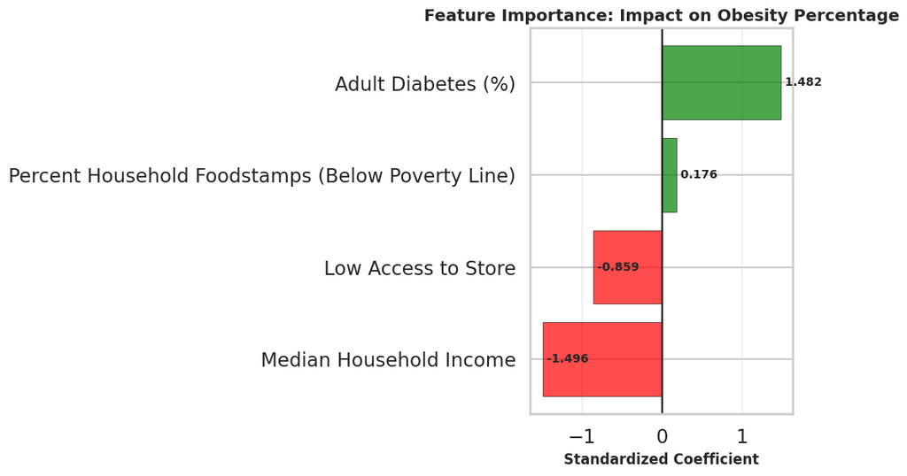

```python
fig, ax = plt.subplots(figsize=(10, 6))
coef_sorted = coef_df.sort_values('Coefficient', ascending=True)
colors = ['green' if c > 0 else 'red' for c in coef_sorted['Coefficient']]

ax.barh(coef_sorted['Feature'], coef_sorted['Coefficient'],
        color=colors, alpha=0.7, edgecolor='black', linewidth=0.5)
ax.set_xlabel('Standardized Coefficient', fontsize=12, fontweight='bold')
ax.set_title('Feature Importance: Impact on Obesity Percentage', fontsize=14, fontweight='bold')
ax.axvline(x=0, color='black', linestyle='-', linewidth=1.5)
ax.grid(True, alpha=0.3, axis='x')

for i, (feature, coef) in enumerate(zip(coef_sorted['Feature'], coef_sorted['Coefficient'])):
    ax.text(coef, i, f' {coef:.3f}', va='center', fontsize=10, fontweight='bold')

plt.tight_layout()
plt.show()
```

With this information, we can generate the linear equation for the model.

```python
intercept = model.intercept_
print("\nLinear Regression Equation:")
print(f"Obesity(%) = {intercept:.4f}", end="")
for idx, row in coef_df.iterrows():
    coef = row['Coefficient']
    feature = row['Feature']
    print(f" {coef:+.4f} × {feature }", end="")
print()
```

```
Linear Regression Equation:
Obesity(%) = 29.2824 -1.4958 × Median Household Income +1.4819 × Adult Diabetes (%) -0.8586 × Low Access to Store +0.1758 × Percent Household Foodstamps (Below Poverty Line)
```

Now we can do something interesting: perform predictions on a state level to analyze if there are any trends according to the state a person lives in. First let's create a dataframe caled `state_results` that stores all analysis results for each state. it provides the actual results and the predicted values as well as the error in the prediction.

```python
state_results = pd.DataFrame({
    'state': state_names,
    'income': x_o.loc[x_o.index,"Median Household Income"].values,
    'diabetes_pct': x_o.loc[x_o.index,"Adult Diabetes (%)"].values,
    'food_stamps_pct': x_o.loc[x_o.index,"Percent Household Foodstamps (Below Poverty Line)"].values,
    'actual_obesity': all_actuals,
    'predicted_obesity': all_predictions,
    'residual': all_actuals - all_predictions,
    'abs_residual': np.abs(all_actuals - all_predictions),
    'pct_error': ((all_actuals - all_predictions) / all_actuals * 100)
})
```

```python
state_results.head(3)
```

|  | state | income | diabetes_pct | food_stamps_pct | actual_obesity | predicted_obesity | residual | abs_residual | pct_error |
| --- | --- | --- | --- | --- | --- | --- | --- | --- | --- |
| 0 | Texas | 56023.764559 | 7.581496 | 7.932985 | 32.4 | 28.366620 | 4.033380 | 4.033380 | 12.448702 |
| 1 | California | 67333.661390 | 7.796552 | 5.095669 | 24.2 | 25.555161 | -1.355161 | 1.355161 | -5.599838 |
| 2 | Kentucky | 45285.802536 | 9.130000 | 11.107604 | 34.6 | 33.109709 | 1.490291 | 1.490291 | 4.307200 |

Let's explore Median Household Income. We can make a graph that displays the state-level trends of obesity rate against Median Household Income.

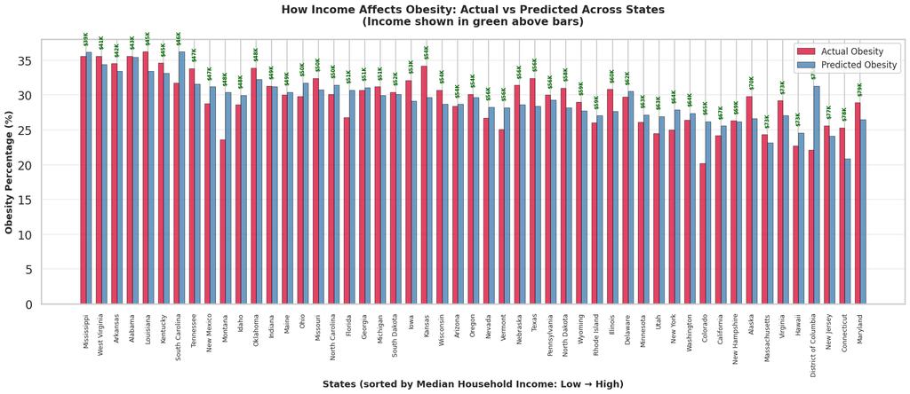

```
States are ordered by income: Mississippi ($38,910) to Maryland ($79,137)
```

```python
import matplotlib.pyplot as plt
import numpy as np

# Sort states by income (low to high)
sorted_states = state_results.sort_values('income')

fig, ax = plt.subplots(figsize=(18, 8))

x = np.arange(len(sorted_states))
width = 0.35

# Create bars for actual and predicted obesity
bars1 = ax.bar(x - width/2, sorted_states['actual_obesity'], width,
               label='Actual Obesity', color='crimson', alpha=0.8, edgecolor='black', linewidth=0.5)
bars2 = ax.bar(x + width/2, sorted_states['predicted_obesity'], width,
               label='Predicted Obesity', color='steelblue', alpha=0.8, edgecolor='black', linewidth=0.5)

# Add income labels on top of bars
for i, (idx, row) in enumerate(sorted_states.iterrows()):
    income_label = f"${row['income']/1000:.0f}K"
    max_height = max(row['actual_obesity'], row['predicted_obesity'])
    ax.text(i, max_height + 1, income_label,
            ha='center', fontsize=7, rotation=90, va='bottom',
            fontweight='bold', color='darkgreen')

# Customize
ax.set_xlabel('States (sorted by Median Household Income: Low → High)',
              fontsize=13, fontweight='bold')
ax.set_ylabel('Obesity Percentage (%)', fontsize=13, fontweight='bold')
ax.set_title('How Income Affects Obesity: Actual vs Predicted Across States\n(Income shown in green above bars)',
             fontsize=15, fontweight='bold', pad=20)
ax.set_xticks(x)
ax.set_xticklabels(sorted_states['state'], rotation=90, fontsize=9, ha='center')
ax.legend(fontsize=12, loc='upper right')
ax.grid(True, alpha=0.3, axis='y')


plt.tight_layout()
plt.show()

print(f"States are ordered by income: {sorted_states['state'].iloc[0]} (${sorted_states['income'].iloc[0]:,.0f}) to {sorted_states['state'].iloc[-1]} (${sorted_states['income'].iloc[-1]:,.0f})")
```

This chart highlights how a state's median household income affects it's obesity percentage. Overall, as the state's median household income increases, the obesity rate decreases. This could be due to the higher access of resources or food quality that decreases the obesity rates.

Next we will add an interpretation column that categorizes how far off each prediction was. It uses the residuals column to show how far off the prediction was from the actual result.

```python
# Add interpretation
def interpret_residual(residual):
    if residual > 3:
        return "Much Higher Than Expected"
    elif residual > 1:
        return "Higher Than Expected"
    elif residual > -1:
        return "As Expected"
    elif residual > -3:
        return "Lower Than Expected"
    else:
        return "Much Lower Than Expected"

state_results['interpretation'] = state_results['residual'].apply(interpret_residual)
```

Let's analyze the results for the first 5 states:

```python
print(f"\nSample Results (first 5 states):")
print(state_results[['state', 'actual_obesity', 'predicted_obesity',
                      'residual', 'interpretation']].head().to_string(index=False))
```

```
Sample Results (first 5 states):
     state  actual_obesity  predicted_obesity  residual            interpretation
     Texas            32.4          28.366620  4.033380 Much Higher Than Expected
California            24.2          25.555161 -1.355161       Lower Than Expected
  Kentucky            34.6          33.109709  1.490291      Higher Than Expected
   Georgia            30.7          31.061881 -0.361881               As Expected
 Wisconsin            30.7          28.706809  1.993191      Higher Than Expected
```

The model performance is definetly mixed. To get a better feel of the variation, we'll analyze the model's accuracy for the actual top 5 highest and bottom 5 lowest obesity rates and the predictions generated by the model.

```python
print(f"\nStates with HIGHEST Actual Obesity:")
top_obesity = state_results.nlargest(5, 'actual_obesity')
for i, (idx, row) in enumerate(top_obesity.iterrows(), 1):
    print(f"  {i}. {row['state']}: {row['actual_obesity']:.1f}% "
          f"(predicted: {row['predicted_obesity']:.1f}%, "
          f"error: {row['residual']:+.1f})")

print(f"\nStates with LOWEST Actual Obesity:")
bottom_obesity = state_results.nsmallest(5, 'actual_obesity')
for i, (idx, row) in enumerate(bottom_obesity.iterrows(), 1):
    print(f"  {i}. {row['state']}: {row['actual_obesity']:.1f}% "
          f"(predicted: {row['predicted_obesity']:.1f}%, "
          f"error: {row['residual']:+.1f})")
```

```
States with HIGHEST Actual Obesity:
  1. Louisiana: 36.2% (predicted: 33.4%, error: +2.8)
  2. Mississippi: 35.6% (predicted: 36.1%, error: -0.5)
  3. West Virginia: 35.6% (predicted: 34.4%, error: +1.2)
  4. Alabama: 35.6% (predicted: 35.4%, error: +0.2)
  5. Kentucky: 34.6% (predicted: 33.1%, error: +1.5)

States with LOWEST Actual Obesity:
  1. Colorado: 20.2% (predicted: 26.2%, error: -6.0)
  2. District of Columbia: 22.1% (predicted: 31.3%, error: -9.2)
  3. Hawaii: 22.7% (predicted: 24.6%, error: -1.9)
  4. Montana: 23.6% (predicted: 30.4%, error: -6.8)
  5. California: 24.2% (predicted: 25.6%, error: -1.4)
```

Here are the states in which the model performed the worse. This could again be due to the model's ignorance of outside factors.

```python
print(f"\nStates where the model performed WORST:")
worst_predictions = state_results.nlargest(5, 'abs_residual')
for i, (idx, row) in enumerate(worst_predictions.iterrows(), 1):
    print(f"  {i}. {row['state']}")
    print(f"     Actual: {row['actual_obesity']:.1f}%, Predicted: {row['predicted_obesity']:.1f}%")
    print(f"     Absolute Error: {row['abs_residual']:.1f} percentage points")
    print(f"     Percentage Error: {row['pct_error']:.1f}%")
    print(f"     Features: Income=${row['income']:,.0f}, "
          f"Diabetes={row['diabetes_pct']:.1f}%, "
          f"Food Stamps={row['food_stamps_pct']:.1f}%")
```

```
States where the model performed WORST:
  1. District of Columbia
     Actual: 22.1%, Predicted: 31.3%
     Absolute Error: 9.2 percentage points
     Percentage Error: -41.6%
     Features: Income=$75,466, Diabetes=8.8%, Food Stamps=8.7%
  2. Montana
     Actual: 23.6%, Predicted: 30.4%
     Absolute Error: 6.8 percentage points
     Percentage Error: -28.7%
     Features: Income=$47,646, Diabetes=7.2%, Food Stamps=6.0%
  3. Colorado
     Actual: 20.2%, Predicted: 26.2%
     Absolute Error: 6.0 percentage points
     Percentage Error: -29.7%
     Features: Income=$64,958, Diabetes=6.6%, Food Stamps=4.5%
  4. Kansas
     Actual: 34.2%, Predicted: 29.6%
     Absolute Error: 4.6 percentage points
     Percentage Error: 13.4%
     Features: Income=$53,886, Diabetes=8.0%, Food Stamps=6.0%
  5. South Carolina
     Actual: 31.7%, Predicted: 36.2%
     Absolute Error: 4.5 percentage points
     Percentage Error: -14.2%
     Features: Income=$46,297, Diabetes=11.1%, Food Stamps=9.1%
```

Now let's analyze the overall model's performance using visulizations by first looking at how the model's predictions performed in comparison to the actual values.

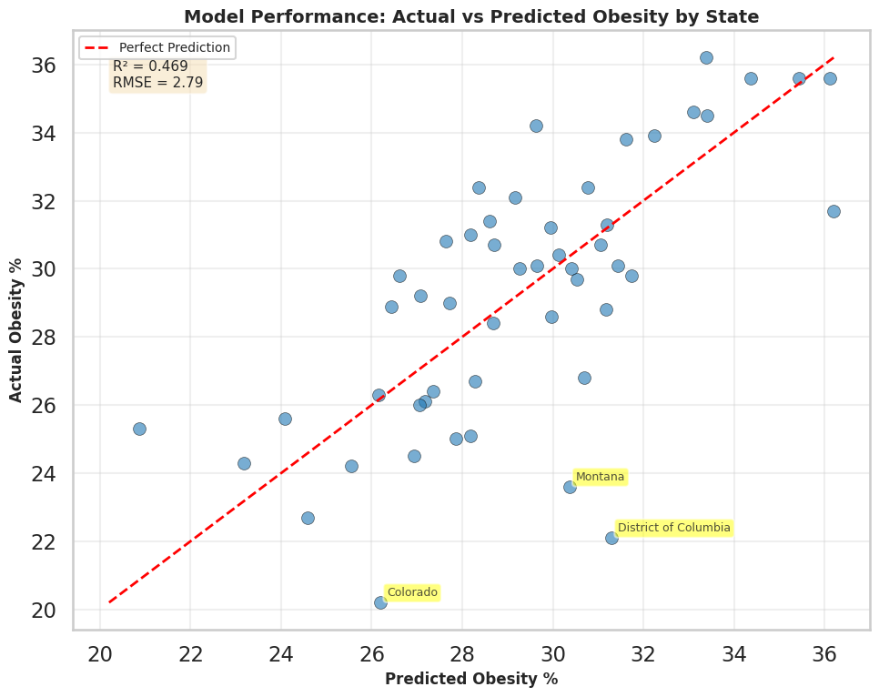

```python
fig, ax = plt.subplots(figsize=(10, 8))
ax.scatter(state_results['predicted_obesity'], state_results['actual_obesity'],
           s=100, alpha=0.6, edgecolors='black', linewidth=0.5)

# Perfect prediction line
min_val = min(state_results['predicted_obesity'].min(),
              state_results['actual_obesity'].min())
max_val = max(state_results['predicted_obesity'].max(),
              state_results['actual_obesity'].max())
ax.plot([min_val, max_val], [min_val, max_val], 'r--', lw=2, label='Perfect Prediction')

# Label worst predictions
worst = state_results.nlargest(3, 'abs_residual')
for idx, row in worst.iterrows():
    ax.annotate(row['state'],
                xy=(row['predicted_obesity'], row['actual_obesity']),
                xytext=(5, 5), textcoords='offset points',
                fontsize=9, alpha=0.8,
                bbox=dict(boxstyle='round,pad=0.3', facecolor='yellow', alpha=0.5))

ax.set_xlabel('Predicted Obesity %', fontsize=12, fontweight='bold')
ax.set_ylabel('Actual Obesity %', fontsize=12, fontweight='bold')
ax.set_title('Model Performance: Actual vs Predicted Obesity by State',
             fontsize=14, fontweight='bold')
ax.legend(fontsize=10)
ax.grid(True, alpha=0.3)
ax.text(0.05, 0.95, f'R² = {cv_r2:.3f}\nRMSE = {cv_rmse:.2f}',
        transform=ax.transAxes, fontsize=11,
        verticalalignment='top',
        bbox=dict(boxstyle='round', facecolor='wheat', alpha=0.5))

plt.tight_layout()
plt.show()
```

This chart highlights that overall the model in general predicts the correct obesity percentage with 2-3 percentage points. There are three outliers (DC, Montana, and Colorado). These are states in which they have low obesity percentages yet were predicted to be higher.

### K-Nearest Neighbors Classifier: Finding Geographic Disparities

Let's investigate whether there are obvious geographic disparities in America regarding obesity rate and its relevant factors.

**Hypothesis:** If obesity-related variables display geographic disparities, then states in the same region will be more similar to each other than to states in other regions.

First, we'll create a distance matrix to see each state's nearest neighbor. This will tell us if the question of geographic disparity is obvious and significant or not.

```python
from sklearn.preprocessing import StandardScaler
from sklearn.metrics import pairwise_distances

# features are numeric data from merged_norace
features = merged_norace.select_dtypes(include=['float64', 'int64'])
X = features.values

# isolate state names from merged_norace to create the dataframe later
states = merged_norace["State"].values

# scale data
scaler = StandardScaler()
X_scaled = scaler.fit_transform(X)

# create distance matrix
dist_matrix = pairwise_distances(X_scaled, metric='euclidean')

# create distance dataframe
dist_df = pd.DataFrame(dist_matrix, index=states, columns=states)

# for each state, list its nearest neighbor and their distance from each other
nearest_states = {}
for state in states:
    # sort distances for this state, ignore itself (distance = 0)
    nearest = dist_df.loc[state].replace(0, np.inf).idxmin()
    distance = dist_df.loc[state, nearest]
    nearest_states[state] = (nearest, distance)

# create dataframe with state name, its nearest neighbor, and the distance
nearest_df = pd.DataFrame([
    {"State": state,
     "Nearest State": nn_state,
     "Distance": dist}
    for state, (nn_state, dist) in nearest_states.items()
])

nearest_df.head()
```

|  | State | Nearest State | Distance |
| --- | --- | --- | --- |
| 0 | Texas | Wisconsin | 1.217949 |
| 1 | California | New Jersey | 2.782376 |
| 2 | Kentucky | West Virginia | 1.031602 |
| 3 | Georgia | Oregon | 1.266646 |
| 4 | Wisconsin | Texas | 1.217949 |

From this dataframe, it can be seen that Texas's nearest neighbor is Wisconsin and California's is New Jersey. In neither of these cases is the state's nearest neighbor in the same region as the state itself. It seems apparent that maybe there aren't glaring geographic disparities with respect to obesity, but we should check if the distance matrix is valid.

Let's take a look at Texas and Wisconsin in the original `merged_norace` dataframe and see if their features are similar.

```python
display(merged_norace[merged_norace["State"] == "Texas"])
merged_norace[merged_norace["State"] == "Wisconsin"]
```

|  | State | Obesity | Percent Unemployed | Median Household Income | Percent Household Foodstamps | Percent Household Foodstamps (Below Poverty Line) | Low Access to Store | Low Income & Low Store Access | No Car & Low Store Access | SNAP & Low Store Access | Number of Food Asistance Sites | Adult Diabetes (%) |
| --- | --- | --- | --- | --- | --- | --- | --- | --- | --- | --- | --- | --- |
| 0 | Texas | 32.4 | 7.392127 | 56023.764559 | 14.90689 | 7.932985 | 26801.99142 | 9462.35378 | 587.351788 | 1775.916041 | 0.003937 | 7.581496 |

|  | State | Obesity | Percent Unemployed | Median Household Income | Percent Household Foodstamps | Percent Household Foodstamps (Below Poverty Line) | Low Access to Store | Low Income & Low Store Access | No Car & Low Store Access | SNAP & Low Store Access | Number of Food Asistance Sites | Adult Diabetes (%) |
| --- | --- | --- | --- | --- | --- | --- | --- | --- | --- | --- | --- | --- |
| 4 | Wisconsin | 30.7 | 7.148843 | 53898.889209 | 14.766916 | 7.258907 | 16721.917494 | 4186.9939 | 562.90979 | 1349.64368 | 0.486111 | 7.401389 |

Texas and Wisconsin's features are, indeed, very similar across the board. The only glaring dissimilarities are 'Low Access to Store' and 'Low Income & Low Store Access,' but these are population count variables. With Texas being much larger than Wisconsin in population, it is only natural that Texas has larger values for these variables. Additionally, the scaling in the original distance matrix should have addressed these concerns.

It is becoming more clear that maybe region won't help us gain clear insights when it comes to obesity rate, but we will continue building the classifier to see whether a higher number of nearest neighbors will yield different results.

Each state must be mapped to a region. These regions are decided according to the U.S. Census Bureau's '[Census Regions and Divisions of the United States](https://www2.census.gov/geo/pdfs/maps-data/maps/reference/us_regdiv.pdf).'

```python
# define the regions
region_map = {
    # Northeast
    'Maine':'New England', 'New Hampshire':'New England', 'Vermont':'New England',
    'Massachusetts':'New England', 'Rhode Island':'New England', 'Connecticut':'New England',
    'New York':'Mid-Atlantic', 'New Jersey':'Mid-Atlantic', 'Pennsylvania':'Mid-Atlantic',

    # Midwest
    'Ohio':'East North Central', 'Indiana':'East North Central', 'Illinois':'East North Central',
    'Michigan':'East North Central', 'Wisconsin':'East North Central',
    'Minnesota':'West North Central', 'Iowa':'West North Central', 'Missouri':'West North Central',
    'North Dakota':'West North Central', 'South Dakota':'West North Central',
    'Nebraska':'West North Central', 'Kansas':'West North Central',

    # South
    'Delaware':'South Atlantic', 'Maryland':'South Atlantic', 'District of Columbia':'South Atlantic',
    'Virginia':'South Atlantic', 'West Virginia':'South Atlantic', 'North Carolina':'South Atlantic',
    'South Carolina':'South Atlantic', 'Georgia':'South Atlantic', 'Florida':'South Atlantic',
    'Kentucky':'East South Central', 'Tennessee':'East South Central', 'Mississippi':'East South Central',
    'Alabama':'East South Central',
    'Oklahoma':'West South Central', 'Texas':'West South Central', 'Arkansas':'West South Central',
    'Louisiana':'West South Central',

    # West
    'Idaho':'Mountain', 'Montana':'Mountain', 'Wyoming':'Mountain', 'Nevada':'Mountain',
    'Utah':'Mountain', 'Colorado':'Mountain', 'Arizona':'Mountain', 'New Mexico':'Mountain',
    'Alaska':'Pacific', 'Washington':'Pacific', 'Oregon':'Pacific', 'California':'Pacific',
    'Hawaii':'Pacific'
}

# map regions to 'merged_norace' dataframe
merged_norace['Region'] = merged_norace['State'].map(region_map)
# map regions to 'nearest_df' dataframe
nearest_df['Region'] = nearest_df['State'].map(region_map)
# map nearest neighbor to its region
nearest_df['Nearest Region'] = nearest_df['Nearest State'].map(region_map)
```

Below is a depiction of the regional mapping that the Census Bureau adopts.

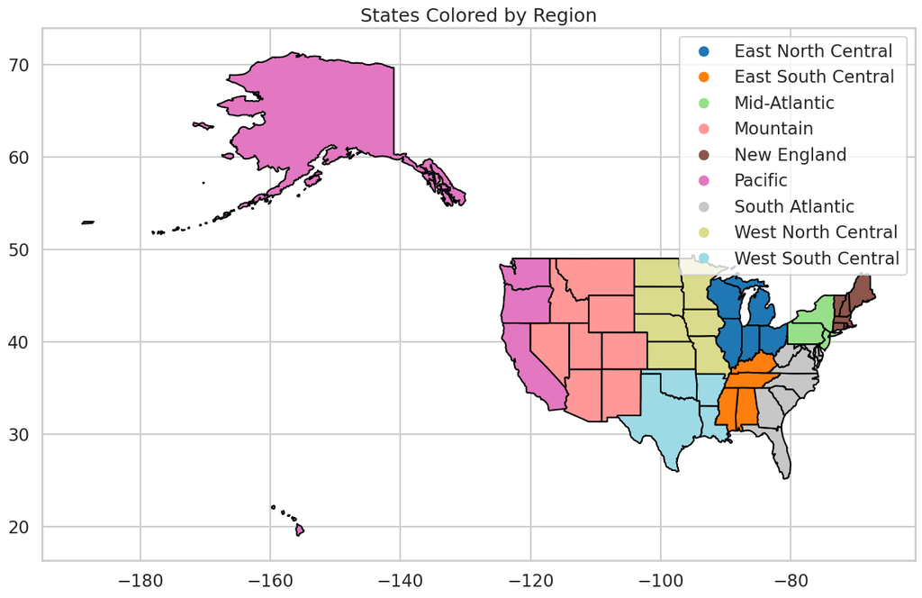

```python
import geopandas as gpd
import matplotlib.pyplot as plt

# Load US states geometry
states_gdf = gpd.read_file("https://raw.githubusercontent.com/PublicaMundi/MappingAPI/master/data/geojson/us-states.json")

# Merge your region info
states_gdf = states_gdf.merge(nearest_df[['State', 'Region']], left_on='name', right_on='State')

# Plot by region
fig, ax = plt.subplots(1, 1, figsize=(15,10))
states_gdf.plot(column='Region', cmap='tab20', legend=True, edgecolor='black', ax=ax)
plt.title("States Colored by Region")
plt.show()
```

After mapping, we will find out whether or not most states' nearest neighbors are located within the same region as the state.

```python
# states whether the state is in the same region as its nearest neighbor
# is the state's region == nearest neighbor's region? true/false
nearest_df['Same_Region'] = nearest_df['Region'] == nearest_df['Nearest Region']

display(nearest_df.head())

# count up the number of true & false to see whether most states' neighbors
# are in the same region as the state
nearest_df.Same_Region.value_counts()
```

|  | State | Nearest State | Distance | Region | Nearest Region | Same_Region |
| --- | --- | --- | --- | --- | --- | --- |
| 0 | Texas | Wisconsin | 1.217949 | West South Central | East North Central | False |
| 1 | California | New Jersey | 2.782376 | Pacific | Mid-Atlantic | False |
| 2 | Kentucky | West Virginia | 1.031602 | East South Central | South Atlantic | False |
| 3 | Georgia | Oregon | 1.266646 | South Atlantic | Pacific | False |
| 4 | Wisconsin | Texas | 1.217949 | East North Central | West South Central | False |

| Same_Region | count |
| --- | --- |
| False | 38 |
| True | 13 |

**dtype:** int64

Most of the states' nearest neighbors do not lie within the same region as the state, but let's see the instances where the nearest neighbor is within the same region as the state. This will show us if there are states disproportionately affected by obesity.

```python
# only show rows where "Same_Region" == True
nearest_df[nearest_df["Same_Region"]]
```

|  | State | Nearest State | Distance | Region | Nearest Region | Same_Region |
| --- | --- | --- | --- | --- | --- | --- |
| 12 | Florida | Delaware | 2.620251 | South Atlantic | South Atlantic | True |
| 14 | Montana | Idaho | 1.672842 | Mountain | Mountain | True |
| 16 | Nebraska | Iowa | 1.148556 | West North Central | West North Central | True |
| 21 | Iowa | South Dakota | 0.955141 | West North Central | West North Central | True |
| 22 | South Dakota | Iowa | 0.955141 | West North Central | West North Central | True |
| 24 | Mississippi | Alabama | 1.461014 | East South Central | East South Central | True |
| 25 | Colorado | Utah | 1.567144 | Mountain | Mountain | True |
| 32 | Massachusetts | Connecticut | 1.029027 | New England | New England | True |
| 34 | Connecticut | Massachusetts | 1.029027 | New England | New England | True |
| 43 | Maryland | Virginia | 2.488595 | South Atlantic | South Atlantic | True |
| 44 | Delaware | Florida | 2.620251 | South Atlantic | South Atlantic | True |
| 46 | Kansas | Iowa | 1.104402 | West North Central | West North Central | True |
| 49 | North Dakota | Nebraska | 1.241694 | West North Central | West North Central | True |

This indicates that there probably are not clean geographic clusters when it comes to obesity in America when taking in all its relevant factors in as well, but we will continue to build the model and see whether adding more nearest neighbors yields different results.

```
best k-value for accuracy: 5
```

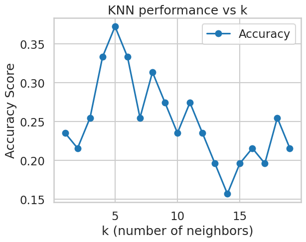

```python
from sklearn.feature_extraction import DictVectorizer
from sklearn.preprocessing import StandardScaler
from sklearn.neighbors import KNeighborsClassifier
from sklearn.model_selection import cross_validate
from sklearn.metrics import make_scorer, f1_score, accuracy_score

# load data, define features, and define the target for learning
feature_cols = [
    'Obesity',
    'Percent Unemployed',
    'Median Household Income',
    'Percent Household Foodstamps',
    'Percent Household Foodstamps (Below Poverty Line)',
    'Low Access to Store',
    'Low Income & Low Store Access',
    'No Car & Low Store Access',
    'SNAP & Low Store Access',
    'Number of Food Asistance Sites',
    'Adult Diabetes (%)']

# prepare X and y
X_dict = merged_norace[feature_cols].to_dict(orient='records')
y = merged_norace["Region"].values

# vectorize and standardize
vec = DictVectorizer(sparse=False)
X = vec.fit_transform(X_dict)

scaler = StandardScaler()
X_sc = scaler.fit_transform(X)

# make accuracy scorer using make_scorer
accuracy_scorer = make_scorer(accuracy_score)

# consider classifiers for k = 1 to 20
k_values = range(1, 20)
accuracy_scores = []

for k in k_values:
    model = KNeighborsClassifier(n_neighbors=k)
    # cross-validate the model using 3-fold validation
    scores = cross_validate(
        model, X_sc, y,
        cv=3,
        scoring={'accuracy': accuracy_scorer},
        return_train_score=False
    )
    accuracy_scores.append(scores['test_accuracy'].mean())

# find and print best k-values for accuracy and F1 (S) scores
best_k_acc = k_values[np.argmax(accuracy_scores)]
print(f"best k-value for accuracy: {best_k_acc}")

# plot
plt.plot(k_values, accuracy_scores, marker='o', label='Accuracy')
plt.xlabel('k (number of neighbors)')
plt.ylabel('Accuracy Score')
plt.title('KNN performance vs k')
plt.legend()
plt.grid(True)
plt.show()
```

From the graph above, it seems that 5 neighbors is the optimal number for this k-NN classifier according to 3-fold validation accuracy. We will move forward with a 5-nearest neighbors classifier and evaluate.

```python
from sklearn.model_selection import StratifiedKFold, cross_val_predict
from sklearn.neighbors import KNeighborsClassifier
from sklearn.metrics import accuracy_score, classification_report, confusion_matrix

# k-fold cross-validation
kfold = StratifiedKFold(n_splits=3, shuffle=True, random_state=42)  # 3-fold CV
knn = KNeighborsClassifier(n_neighbors=5)

# cross_val_predict gives predictions for each fold
y_pred = cross_val_predict(knn, X_scaled, y, cv=kfold)

# evaluation
acc = accuracy_score(y, y_pred)
print(f"Cross-validated Accuracy: {acc:.2f}\n")
print("Classification Report:\n", classification_report(y, y_pred))
display("Confusion Matrix:", confusion_matrix(y, y_pred))
```

```
Cross-validated Accuracy: 0.33

Classification Report:
                     precision    recall  f1-score   support

East North Central       0.15      0.40      0.22         5
East South Central       0.60      0.75      0.67         4
      Mid-Atlantic       0.00      0.00      0.00         3
          Mountain       0.50      0.38      0.43         8
       New England       0.17      0.17      0.17         6
           Pacific       0.00      0.00      0.00         5
    South Atlantic       0.50      0.22      0.31         9
West North Central       0.50      0.71      0.59         7
West South Central       0.33      0.25      0.29         4

          accuracy                           0.33        51
         macro avg       0.31      0.32      0.30        51
      weighted avg       0.34      0.33      0.32        51
```

```
'Confusion Matrix:'
```

```
array([[2, 0, 0, 0, 0, 0, 1, 1, 1],
       [1, 3, 0, 0, 0, 0, 0, 0, 0],
       [2, 0, 0, 0, 1, 0, 0, 0, 0],
       [2, 0, 0, 3, 1, 0, 0, 2, 0],
       [0, 0, 1, 2, 1, 1, 1, 0, 0],
       [2, 0, 0, 0, 2, 0, 0, 1, 0],
       [2, 1, 1, 0, 1, 1, 2, 1, 0],
       [0, 0, 0, 1, 0, 0, 0, 5, 1],
       [2, 1, 0, 0, 0, 0, 0, 0, 1]])
```

In terms of precision, the most accurately predicted East South Central, Mountain, South Atlantic, and West North Central states; though, these were only correctly identified 50-60% of the time. This is most likely due to the high recall that the model has for East South Central and West North Central states, which also had the highest F1 scores.

**Conclusion**: Overall, the kNN classifier performs poorly, with an accuracy of only 0.33, and it failed to identify several regions, including the Mid-Atlantic and Pacific. Regions such as East South Central and West North Central show higher precision and recall, most likely due to their more internally consistent socioeconomic and health profiles, but the majority of regions do not form distinct clusters in terms of the features used. This suggests that the obesity-related variables in `merged_norace` do not exhibit strong geographic separation. As a result, the original hypothesis, that states are more similar to others within their geographic region, is not supported by the model’s performance, and we cannot conclusively say that there are geographic disparities with regard to obesity in America.

# Insight & Policy Decision

This tutorial showed that Median Household Income and Adult Diabetes Rate were the strongest indicators of obesity on a state-wide level. As adult diabetes rate is seen as a consequence of obesity and an indicator of obesity prevalence, not a factor contributing to the nation's obesity rate, it can be said that lower-income individuals are more susceptible to obesity.

With America’s issue of the shrinking middle class ([Pew Research Center](https://www.pewresearch.org/race-and-ethnicity/2024/05/31/the-state-of-the-american-middle-class/)), more individuals are disproportionately at risk for obesity. This increased income inequality means that the top 1% of earners in America have accumulated over 1000 times the wealth of the bottom 20% over the past 35 years ([Forbes](https://www.forbes.com/sites/josiecox/2025/11/03/income-inequality-is-surging-in-the-us-new-oxfam-report-shows/)). Lower-income households tend to struggle with food access and access to nutrient-rich foods, which puts them at higher risk for obesity already, but poverty is linked to poor patient experience because of barriers to transportation for attending medical appointments, lack of health insurance, and inability to afford long-term medication and care ([National Health Council](https://www.forbes.com/sites/josiecox/2025/11/03/income-inequality-is-surging-in-the-us-new-oxfam-report-shows/)). Even if lower-income individuals wanted to get treatment for issues related to diabetes or to take initiative of their health by preventing it through medical treatment, they still would not have access to quality care. This is an example of how systemic inequity results in a positive feedback loop of poor health outcomes for susceptible populations.

As much as obesity is seen as an individual health issue, there are ways to address it on a national scale: addressing the wealth gap and finding ways to mitigate it through accessible healthcare and food distribution. For more insights about how this can be done, Johns Hopkins Bloomberg School of Public Health has released a study about how raising the minimum wage and increasing efforts to promote access to healthy foods can both address the income gap and lower the prevalence of obesity in America ([Johns Hopkins](https://publichealth.jhu.edu/2024/new-study-highlights-link-between-minimum-wage-income-inequality-and-obesity-rates-across-us-counties)). The CDC has also encouraged people to get involved in efforts that promote healthy eating and increased physical activity on a community-wide scale ([CDC](https://www.cdc.gov/obesity/php/about/obesity-strategies-what-can-be-done.html)). Additionally, all references to research have been cited through links, and these insights provided by the NIH, CDC, Pew Research Center, Forbes, etc., have been integral to our understanding of obesity as a systemic issue.

```python
!jupyter nbconvert "/content/drive/MyDrive/Colab Notebooks/Data Science Project/Moore_Nguyen_Data_Science_Project.ipynb" --to html --output index.html
```

```
[NbConvertApp] Converting notebook /content/drive/MyDrive/Colab Notebooks/Data Science Project/Moore_Nguyen_Data_Science_Project.ipynb to html
[NbConvertApp] WARNING | Alternative text is missing on 18 image(s).
[NbConvertApp] Writing 3673311 bytes to /content/drive/MyDrive/Colab Notebooks/Data Science Project/index.html
```